# Práctica 2: Limpieza y validación de los datos

Luis Manuel Pérez Geraldino y Sergi Ramirez Mitjans

16 de Mayo de 2019

# 1. Descripción del dataset

El dataset que a continuación se va a describir, se a obtenido mediante *web scrapping* en la práctica 1 de esta misma asignatura por lo tanto está práctica se tratará de realizar la limpieza del dataset que se consiguió desarrollar en etapas anteriores de esta asignatura.

El conjunto de datos obtenido recoge los medicamentos con más facturación en el mundo farmacéutico. A la vez también esta incorporado los medicamentos más consumidos en España. Este dataset es variable ya que se tendrán tantos medicamentos como el código demande. Esto es posible ya que el código esta preparado para hacer de buscador y extractor de aquellos medicamentos que se pasen por parámetros. Algunas variables de las que encontramos en el dataset sería el precio, nombre del medicamente, genérico o url del Vademecum.

```r
# Leemos los datos para guardar
datos <- read.csv2('data/data.csv',  sep = ";", header = T, stringsAsFactors = T, dec = ".", encoding = 'latin1')

# Cambiamos el nombre de las columnas para que puedan ser leibles
cols <- c("Medicamento", "URL", "Presentacion", "Codigo_Nacional", "Tipo", "Generico", "Laboratorio", "Estado", "Fecha_Alta", "Fecha_Baja", "Aportacion_Beneficiario", "Principio_Activo", "PVP", "Precio_Referencia", "Menor_Precio_Agrupacion_Homogenea", "Agrupacion_Homogenea", "Diagnostico_Hospitalario", "Tratamiento_Larga_Duracion", "Control_Medico", "Huerfano", "Enfermedad")
colnames(datos) <- cols
```

A continuación se van a describir el significado de cada variable:

```r
library(readxl)
library(xtable)
archivos <- 'data/codbook_variables.xlsx'
codbook_vademecum <- data.frame(read_excel(archivos, sheet = 1))
codbook <- data.frame(read_excel(archivos, sheet = 2))
codbook <- rbind(codbook_vademecum, codbook)
codbook <- xtable(codbook, include.rownames=FALSE)
align(codbook) <- "|l|l|l|X|"
print(codbook, tabular.environment="tabularx", width="\\textwidth", comment = FALSE)
```

## 2. Objetivos

La creación del estudio de nuestra base de datos contiene diferentes objetivos. A continuación vamos a explicar cada uno de ellos para que tenga sentido el echo de realizar según que prueba estadística o modelo de predicción. Los objetivos son los siguientes:

- Para empezar queremos realizar un estudio para saber si existe o no existe diferencia entre el precio y los grupos tipo de medicamento.
- También queremos hacer un estudio para encontrar existencia diferencias en el precio según el laboratorio que realiza el medicamento.
- Mirar si existe diferencias de precio según la enfermedad que se quiera tratar.
- Agrupar conjunto de medicamentos para detectar patrones subjacentes detrás de ello.
- Intentar hacer una predicción del precio. Este apartado consistirá en realizar un modelo de predicción de precio. Nos servirá a las farmacéuticas para facilitarles el precio que se le debe de asignar a un enfermo según variables del medicamento que va a utilizar.
- Realizar una clasificación de la enfermedad según variables económica y del laboratorio que lo fabrica. Al final queremos hacer este estudio para poder ayudar a las empresas aseguradoras para renovar o no un seguro de salud sabiendo el gasto en medicamentos que realiza el cliente saber que enfermedad tiene.

# 3. Análisis Descriptivo

A continuación vamos a hacer un descriptivo numérico de como son nuestras variables.

```r
# Generamos 3 vectores con la posicion de las columnas según la tipologia de ellas
lista_clase <- sapply(datos, class)

# Generamos diferentes variables
var_factor    <- unname(which(lista_clase %in% c('factor', 'character')))
var_numeric   <- unname(which(lista_clase %in% c('numeric', 'integer')))
```

## 3.1 Variables numéricas

Primoro de todo vamos a realizar un estudio de las variables numéricas que tenemos en nuestro dataset. En él sólo encontramos las variables `PVP`, `Precio_Referencia` y `Menor_Precio_Agrupacion_Homogenea`.

```r
cols <- colnames(datos)[var_numeric]
cols <- cols[which(!cols %in% c('Codigo_Nacional'))]
library(pastecs)
tabla <- round(stat.desc(datos[, cols]), 2)
print(tabla)
```

```
              PVP Precio_Referencia Menor_Precio_Agrupacion_Homogenea
```

nbr.val 1503.00 1462.00 1415.00 nbr.null 0.00 0.00 0.00 nbr.na 0.00 41.00 88.00 min 0.08 0.08 0.67 max 321.89 58.82 111.90 range 321.81 58.74 111.23 sum 15145.04 11976.86 11690.96 median 4.15 4.15 4.15 mean 10.08 8.19 8.26 SE.mean 0.51 0.25 0.26 CI.mean.0.95 1.00 0.49 0.51 var 388.58 91.43 96.39 std.dev 19.71 9.56 9.82 coef.var 1.96 1.17 1.19

```r
tabla <- xtable(tabla, include.rownames=FALSE)
print(tabla, tabular.environment="longtable", comment = FALSE)
```

```r
par(mfrow = c(1, 3))
for(col in cols){
    cat("Descriptivo univariante para la variable ", col)
    grafico <- boxplot(datos[, col], col = "steelblue2", main = col)
}
```

Descriptivo univariante para la variable PVPDescriptivo univariante para la variable Precio_ReferenciaDescriptivo univariante para la variable Menor_Precio_Agrupacion_Homogenea

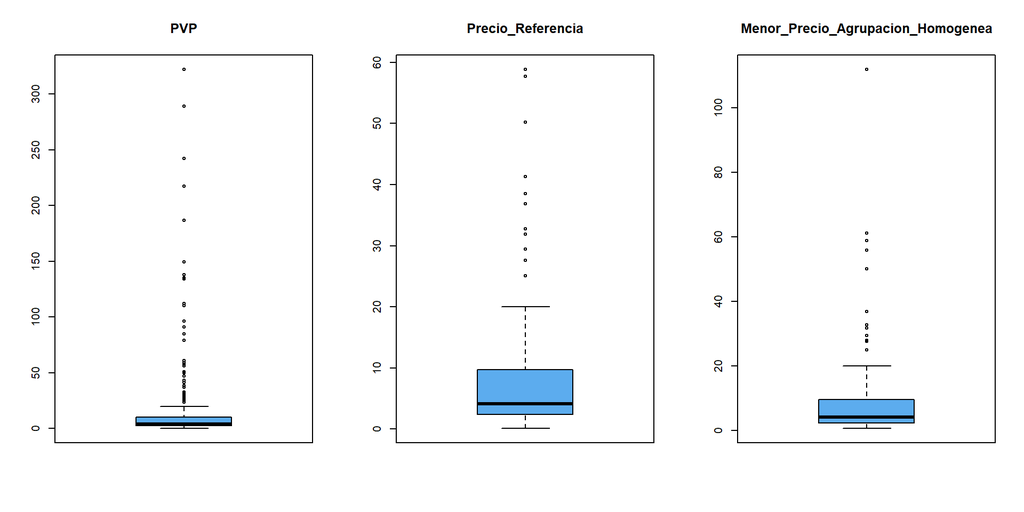

```r
par(mfrow = c(1, 1))
```

Como podemos ver en la tabla de descriptivos, vemos que las variables `Precio_Referencia` y `Menor_Precio_Agrupacion_Homogenea` contienes valores faltantes. Esto nos hará replantearnos la necesidad de imputar o no los valores faltantes de estas variables.

Por lo que respecta a la distribución de los datos numéricos según el boxplot, podemos ver como el precio que viene de la variable `PVP` tiene una distribución más escueta de sus rangos quartílicos pero esto es derivado a que la variable `PVP` contiene valores mucho más altos que en las otras dos variables no las tiene y por lo tanto hace que se detecten outliers y la consecuencia de la forma ‘achatada’ de la distribución de la variable.

## 3.2 Varibles categóricas

A continuación vamos a generar la descriptiva de las variables categóricas. En este apartado realizaremos tablas de frequencia para ver como está distribuido el número de casos para cada categoria. A demás se va a representar mediante barplots (ya que si lo hicieramos con diagrama de sectores no es tan visual ver la proporción correspondiente a cada categoria).

Debido a que tenemos algunas variables con muchas categorias, restringiremos la creación de los gráficos a sólo aquellos que tengan máximo 10 categorias. Esto se debe a que si tenemos muchas categorias el gráfico no es entendible en ningun caso.

También para evitar que no sea leible cada categoria, haremos que el gráfico de barplot sea en horizontal.

Antes de eso, vamos a cambiar el nombre de algunas de las categorias de algunas de las variables para que cuando se representen sean de fácil lectura.

```r
library(plyr)

# Tipo
datos[, 'Tipo'] <- revalue(datos[, 'Tipo'], c("Medicamento Etica" = "Etica",
                           "Medicamento Generico" = "Generico",
                           "Medicamento con Denominacion Generica" = "Denominacion Generica"))
# Estado
datos[, 'Estado'] <- revalue(datos[, 'Estado'], c("BAJA POR NO COMERCIALIZAR" = "BAJA NO COMERCIALIZAR",
                           "SUSPENSION TEMPORAL GENERAL" = "SUSPENSION TEMP GRAL"))
# Enfermedad
datos[, 'Enfermedad'] <- revalue(datos[, 'Enfermedad'],
                         c("COAGULOS SANGUINIOS EN REPOSO" = "ANTICOAGULANTE",
                           "ENFERMEDADES CARDIOVASCULARES" = "ENF. CARDIOVASCULARES",
                           "ENFERMEDADES DE LA ARTERIA CORONARIA" = "ENF. CARDIOVASCULARES",
                           "ENFERMEDADES RESPIRATORIAS" = "ENF. RESPIRATORIAS"))
```

```r
cols <- colnames(datos)[var_factor]

for(col in cols) {
  cat("Descriptivo univariante para la variable", col, "\n")
  tabla_frec <- table(datos[, col], useNA = "ifany")
  longitud <- length(tabla_frec)
  if (longitud <= 16) {
        counts <- data.frame(tabla_frec)
        colnames(counts) <- c('Variables', 'Conteo')
        counts[, 'Porcentaje'] <- round((counts$Conteo/sum(counts$Conteo))*100, 2)
    par(mai=c(1,2,2,2))
    grafico <- barplot((counts$Porcentaje/100) , main = paste0("Barplot de la variable ", col), horiz = TRUE, names.arg = counts$Variables,las = 1, col = "darkblue", xlim = c(0, 1), cex.names = 0.6)
    labels = paste0(counts$Conteo, " (", counts$Porcentaje,"%)")
    text(x = (counts$Porcentaje/100), col = "red", y = grafico, label = labels, pos = 4, cex = 0.65)
  } else {
    cat("El número de categorias de la variable ", col, "es muy grande(", longitud, "). Pasamos a la siguiente variable.\n")
        cat("\n ===============================\n")
  }
}
```

Descriptivo univariante para la variable Medicamento El número de categorias de la variable Medicamento es muy grande( 908 ). Pasamos a la siguiente variable.

=============================== Descriptivo univariante para la variable URL El número de categorias de la variable URL es muy grande( 908 ). Pasamos a la siguiente variable.

=============================== Descriptivo univariante para la variable Presentacion El número de categorias de la variable Presentacion es muy grande( 132 ). Pasamos a la siguiente variable.

=============================== Descriptivo univariante para la variable Tipo

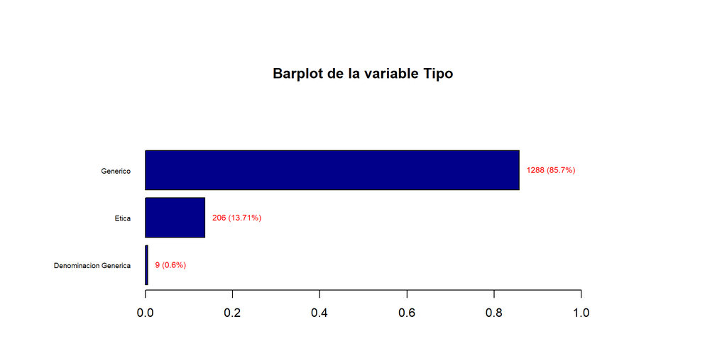

Descriptivo univariante para la variable Laboratorio El número de categorias de la variable Laboratorio es muy grande( 73 ). Pasamos a la siguiente variable.

=============================== Descriptivo univariante para la variable Estado

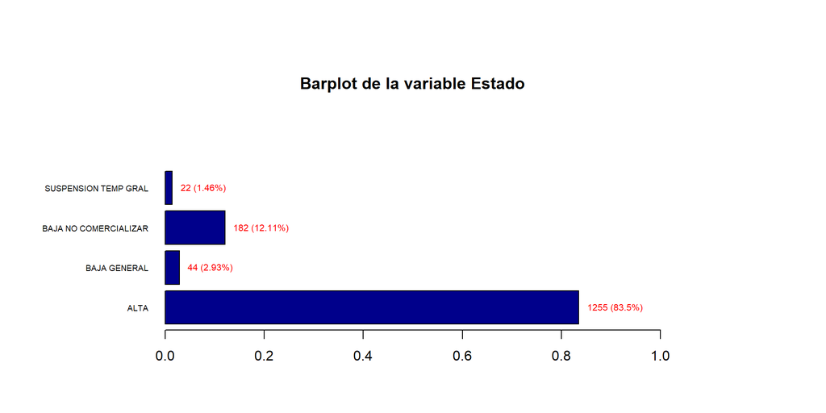

Descriptivo univariante para la variable Fecha_Alta El número de categorias de la variable Fecha_Alta es muy grande( 227 ). Pasamos a la siguiente variable.

=============================== Descriptivo univariante para la variable Fecha_Baja El número de categorias de la variable Fecha_Baja es muy grande( 45 ). Pasamos a la siguiente variable.

=============================== Descriptivo univariante para la variable Aportacion_Beneficiario

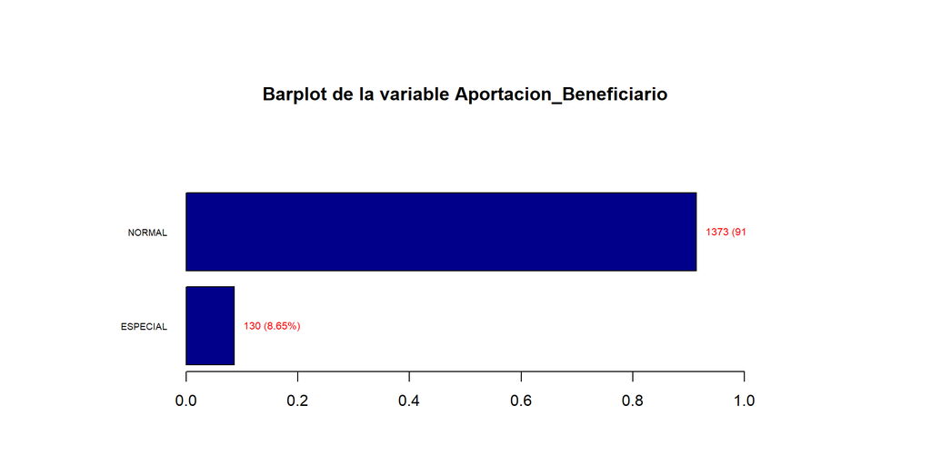

Descriptivo univariante para la variable Principio_Activo El número de categorias de la variable Principio_Activo es muy grande( 53 ). Pasamos a la siguiente variable.

=============================== Descriptivo univariante para la variable Agrupacion_Homogenea El número de categorias de la variable Agrupacion_Homogenea es muy grande( 138 ). Pasamos a la siguiente variable.

=============================== Descriptivo univariante para la variable Diagnostico_Hospitalario

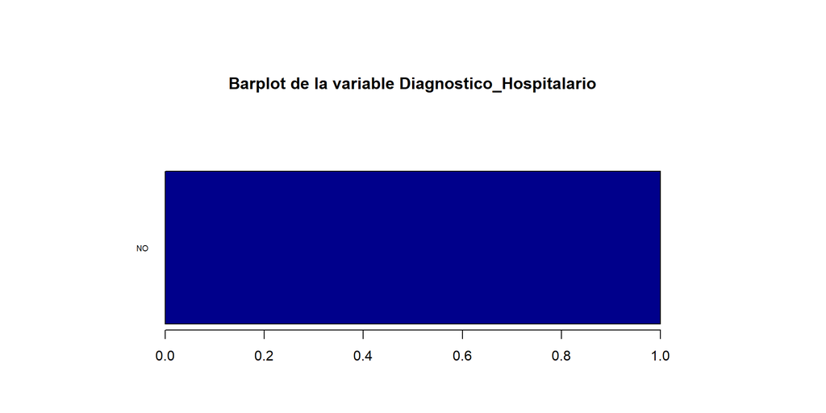

Descriptivo univariante para la variable Tratamiento_Larga_Duracion

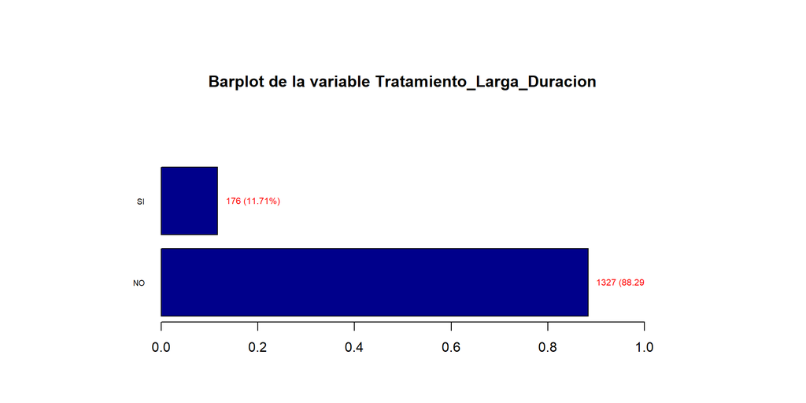

Descriptivo univariante para la variable Control_Medico

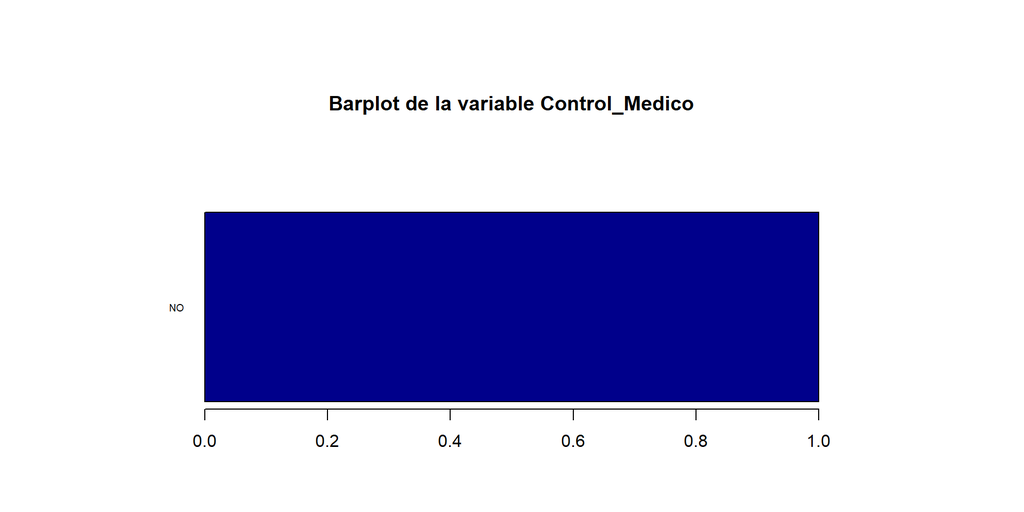

Descriptivo univariante para la variable Huerfano

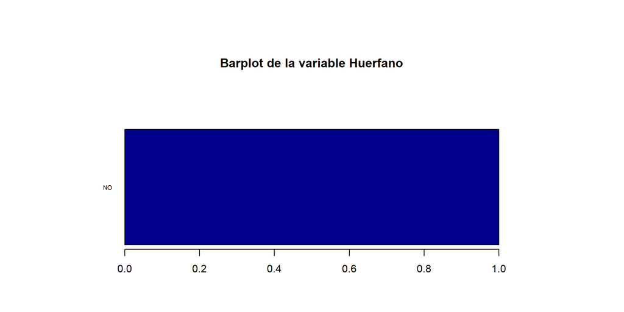

Descriptivo univariante para la variable Enfermedad

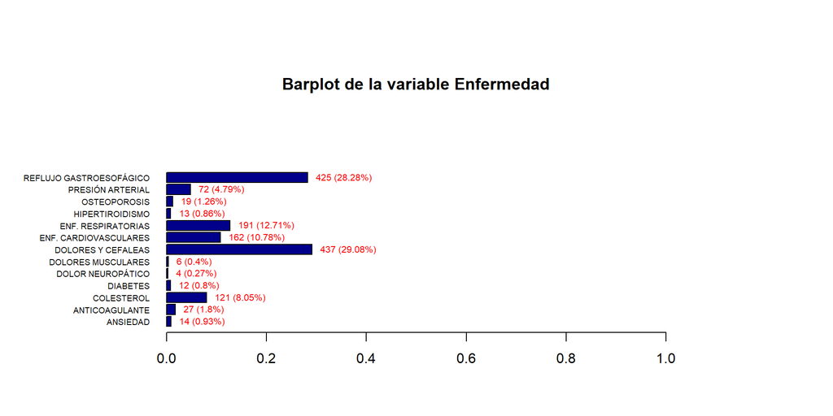

Como podemos observar con el código que se ha ejecutado anteriormente, vemos como tenemos dos problemas en las variables.

1. Las variables `Medicamento` (908), `URL` (908), `Presentacion` (132), `Laboratorio` (73), `Fecha_Alta` (227), `Fecha_Baja` (45), `Principio_Activo` (53), `Agrupacion_Homogenea` (138) son variables con muchas categorias y por lo tanto nos deberemos de plantear si las usamos o no para generar nuestros modelos. En caso de que las quisieramos usar, deberiamos de recategorizar variables para tener un número reducido de ellas.
2. Las variables ``Diagnostico_Hospitalario`, `Control_Medico` y `Huerfano` son variables que sólo tienen 1 categoria. Por lo tanto decidimos no usarlas en nuestro estudio y posteriormente eliminarlas del dataframe.

Viendo los barplots podemos intentar pensar en juntar categorias de variables. En nuestro caso, para la variable `Enfermedad` deberiamos de juntar dichas categorias. Cómo realmente necesitamos decisiones expertas de parte de medicos para poder juntar diagnósticos semejantes, seguiremos adelante el trabajo sin agrupar categorias.

# 4. Análisis Descriptivo Bivariante

A continuación vamos hacer un estudio de como se comportan las variables de nuestro dataset teniendo en cuenta la variable precio (`PVP`). Hemos decidido la variable precio ya que es la variable numérica que utilizaremos para responder a nuestras preguntas e validar nuestros contrastes.

### 4.1 Variables numéricas

A continuación vamos a realizar una matriz de correlaciones para poder detectar variables muy correlacionadas e incluso variables que sean iguales. Este paso también nos servirá para descartar variables que sean muy similares y por lo tanto su correlación sea igual a 1. Este es un método de reducir dimensionalidad. Otra forma sería realizando un análisis de componentes principales (ACP) peró descartamos este método ya que sólo disponemos de 3 variables numéricas.

Para poder llevar a cabo nuestras correlaciones, y ya que hacemos el estudio antes de imputar valores, debemos decir a la instrucción de R `cor` que sólo tenga en cuenta los casos que si se tiene información de ello.

```r
library(xtable)
cols <- c("PVP", "Precio_Referencia", "Menor_Precio_Agrupacion_Homogenea")
correlaciones <- cor(datos[, cols], use = "complete.obs")
tabla <- xtable(correlaciones, include.rownames = FALSE)
print(tabla, tabular.environment="longtable", width="\\textwidth", comment = FALSE)
```

Eliminaremos las variables `Precio_Referencia` y `Menor_Precio_Agrupacion_Homogenea` ya que no tiene sentido que posteriormente se haya de imputar estos valores para que nos quede igual que la variable `PVP`. Por lo tanto no hará tampoco falta imputación de datos faltantes en las variables numéricas.

### 4.1 Variables categóricas

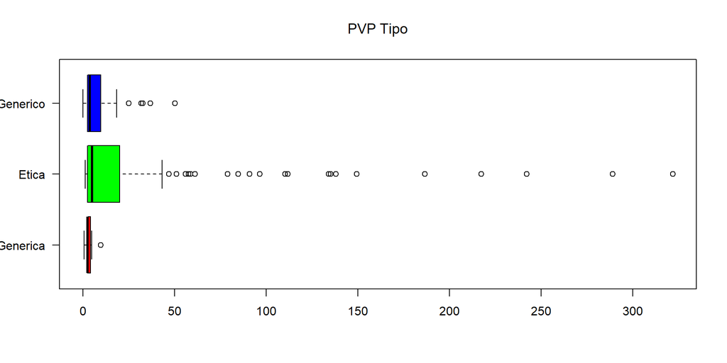

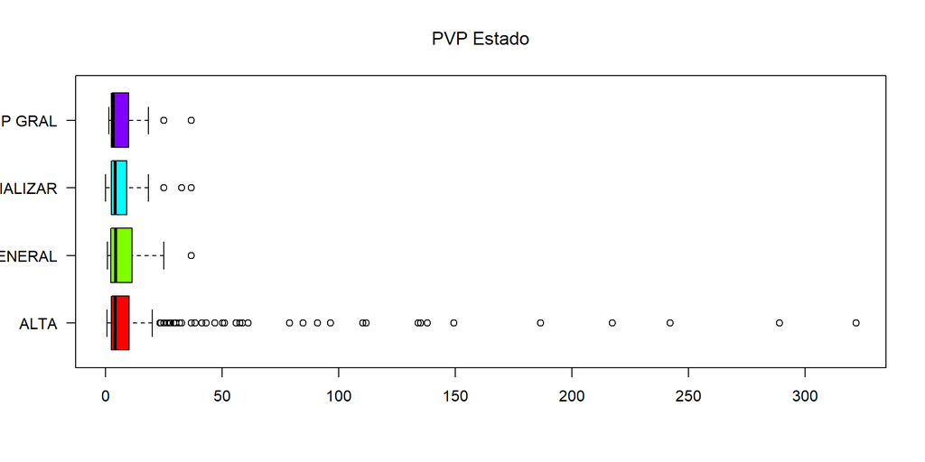

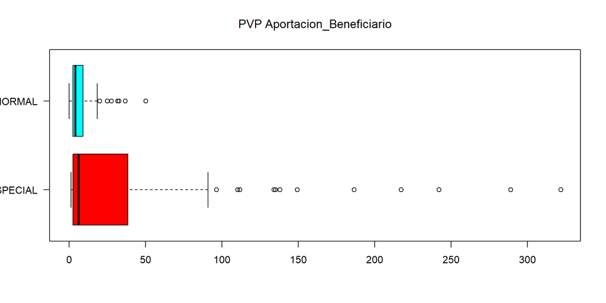

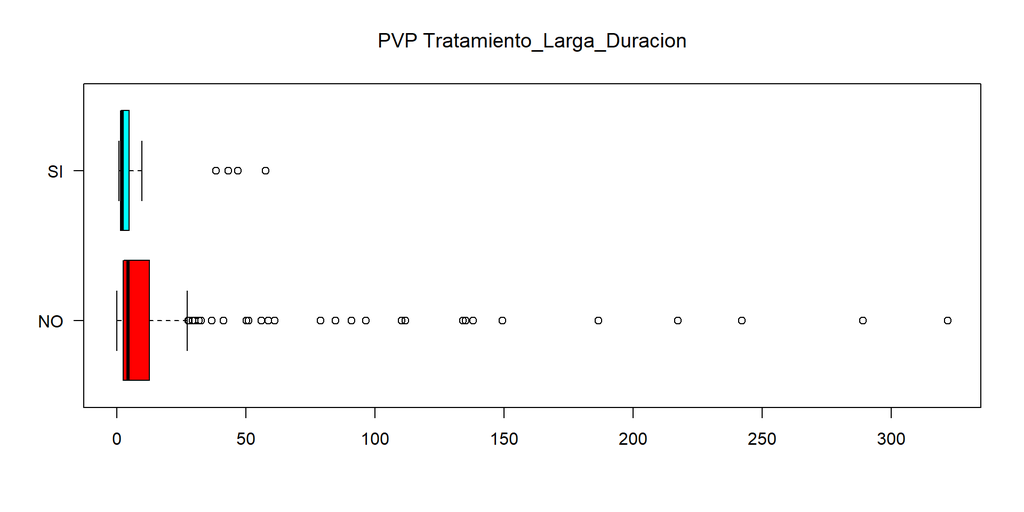

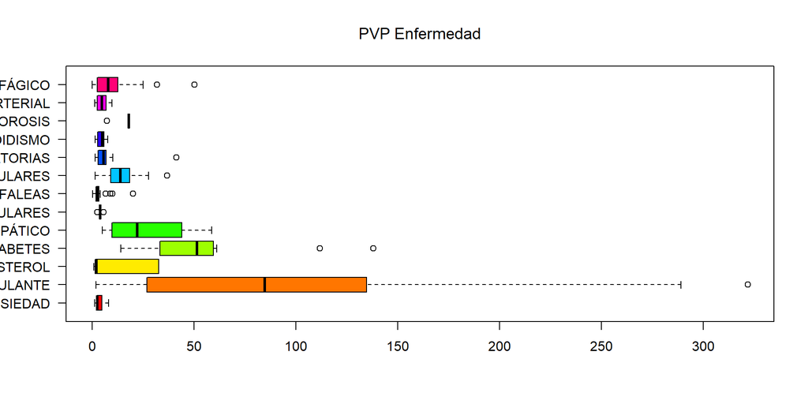

```r
cols <- c("Tipo", "Estado", "Aportacion_Beneficiario", "Tratamiento_Larga_Duracion", "Enfermedad")
for(col in cols) {
  boxplot(formula(paste0("PVP ~", col)) , datos, col = rainbow(length(unique(datos[, col]))), main = formula(paste0("PVP ~", col)), horizontal=TRUE, las = 1, cex.names = 0.34, names.arg = unique(datos[, col]))
}
```

Podemos sacar diferentes conclusiones que nos ayudarán a entender posibles respuestas en le futuro.

Si miramos el gráfico de Enfermedades vemos como los medicamentos anticuagulantes són aquellos que tienes más variabilidad de precios. Esto nos hace pensar que igual dichos medicamentos que intentan evitar esa enfermedad deberian de estudiarse por separado ya que pueden hacer (y lo hacen) obtener outliers en nuestros datos y crear un sesgo por el simple hecho de ser un medicamento anticuagulante. Estos medicamentos, són aquellos medicamentos que necesitan gente especialmente destinada a enfermedades crónicas y por eso en el boxplot de Aportación vemos qu se encontrarian en la categoria ESPECIAL. Además sabemos que los aticuagulantes sirven para espesar la sangre y por lo tanto no se necesita un tratamiento de larga duración para su uso, así lo vemos reflejado en nuestro boxplot.

# 5. Limpieza de los datos

A continuación generamos la etapa de limpieza de datos. En ella se intentará preparar el dataset para poder usarlo para hacer contrastes y predicciones de valores en u futuro. Además en esta etapa se pretende también crear nuevas variables, contrastar que los datos numéricos siguen una distribución normal e detectar posibles outliers de nuestros datos.

## 5.1 Creación de nuevas variables

Primero de todo vamos a discretizar la variable `PVP`.

Aunque sabemos que la discretización de una variable numérica hace que dejes de tener información de la distribución de la variable numérica, para representaciones posteriores necesitamos tener la variable `PVP` discretizada para poder representarla por ello vamos a crear la a continuación.

Cuando hablamos de discretizar una variable, se define como el remplazar variables numéricas a atributos categóricos con etiquetas.

Para realizar la discretización vamos a realizar métodos de clustering. Este tipo de modelo k-means consiste en buscar aquellas clases que sean homogeneas en ellas mismas pero entre ellas sean suficientemente separables.Por lo tanto dividen sus valores en grupos teniendo en cuenta la distribución del atributo y la cercanía de los datos a cada grupo.

```r
library(arules)
# k-means clustering
discretizacion <- discretize(datos[, 'PVP'], method = "cluster", breaks = 2, onlycuts = TRUE)
datos[, 'tram_PVP'] <- cut(datos[, 'PVP'], breaks = discretizacion, include.lowest = TRUE)
```

Seguidamente creamos una variable llamada `tram_presentacion` donde lo que se hará será agrupar categorias de presentación de tal forma tener menos niveles en la variable. Mediante el text mining de la variable `Presentación`.

```r
# ENVASE
datos[, 'tram_presentacion'] <- 'ENVASES'

# INHALADORES/OTROS
patron <- 'inhalador|inhalación|inh|tiras'
qui <- grep(patron, tolower(datos[, 'Presentacion']))
datos[qui, 'tram_presentacion'] <- 'INHALADORES/OTROS'

# INJECTABLES
patron <- 'opa|pluma|plumas|cartucho|cartuchos|jeringa|jeringas|injectables'
qui <- grep(patron, tolower(datos[, 'Presentacion']))
datos[qui, 'tram_presentacion'] <- 'INJECTABLES'

# SOBRES
patron <- 'vial|sobre|sobres'
qui <- grep(patron, tolower(datos[, 'Presentacion']))
datos[qui, 'tram_presentacion'] <- 'SOBRES'

# FRASCO
patron <- 'frasco|frascos|bote|botes|ampolla|ampollas'
qui <- grep(patron, tolower(datos[, 'Presentacion']))
datos[qui, 'tram_presentacion'] <- 'FRASCOS'

# BLÍSTER
patron <- 'blister|blíster|comp|comprimidos|cap|cápsula|cápsulas'
qui <- grep(patron, tolower(datos[, 'Presentacion']))
datos[qui, 'tram_presentacion'] <- 'BLISTER'
```

Seguidamente, generamos la variable `Baja`. Esta variable es una variable dicotómica extraida de la variable `Fecha_Baja` que nos permitirá saber si el medicamento se ha dado de baja en y por lo tanto no se encuentra ni a la venta ni financiado por el sistema nacional de salud.

```r
# Creamos la variable Baja que consiste en si el medicamento esta o no esta dado de baja
datos[, 'Baja'] <- ifelse(datos[, 'Fecha_Baja'] == "", "NO", "SI")
```

El siguiente paso es generar dos nuevas variables. Estas nuevas variables serán la codificación de las variables `Agrupacion_Homogenea` y `Laboratorio`. Hemos tomado esta decisión ya que queremos evitar que por motivos de escritura de las categorias de la variable encontremos varios laboratorios que se refieren al mismo escrito de forma diferente o varias agrupaciones homogeneas que le sucedan lo mismo.

```r
# Separamos el código de la agrupación
codigos <- strsplit(as.character(datos[, 'Agrupacion_Homogenea']), "-")
data = data.frame(codigo = character(), agrupacion = character(), stringsAsFactors=FALSE)

for (i in 1:length(codigos)){
    if(codigos[i][1] == ""){
      data[i, 1] = NA
      data[i, 2] = NA
    } else {
      data[i, 1] = as.character(codigos[[i]][1])
      data[i, 2] = as.character(codigos[[i]][2])
    }
}

datos[, 'Codigo_Agrupacion'] <- data[, 'codigo']
# Aseguraremos el mismo número de dígitos en el código
datos[, 'Codigo_Agrupacion'] <- sprintf("%0.5d", as.numeric(datos[, 'Codigo_Agrupacion']))
```

Seguimos con la variable `Laboratorio`.

```r
# Realizamos la separación por laboratorio
lab <- strsplit(as.character(datos[, 'Laboratorio']), ",")
data = data.frame(codigo = character(), laboratorio = character(), sociedad =  character(), stringsAsFactors = FALSE)

for (i in 1:length(codigos)){
    if(length(lab[[i]]) == 3){
      valor1 = as.character(lab[[i]][1])
      valor2 = as.character(lab[[i]][2])
      valor3 = as.character(lab[[i]][3])
    } else {
      if (length(lab[[i]]) == 2){
      valor1 = as.character(lab[[i]][1])
      valor2 = as.character(lab[[i]][2])
      valor3 = ""
      } else {
      valor1 = ""
      valor2 = as.character(lab[[i]][2])
      valor3 = ""
      }
    }
    data[i, 1] = valor1
    data[i, 2] = valor2
    data[i, 3] = valor3
}

datos[, 'Codigo_Laboratorio'] <- data[, 'codigo']

# Aseguraremos el mismo número de dígitos en el código
datos[, 'Codigo_Laboratorio'] <- sprintf("%0.4d", as.numeric(datos[, 'Codigo_Laboratorio']))
```

Antes de eliminar la variable `Laboratorio`, vamos a aprovechar dicha variable para crear una nueva variable que la llamaremos `Sociedad`. Esta nueva variable consiste en identificar cada medicamento de su laboratorio si el laboratorio es de una Sociedad anónima (S.A.), Sociedad anónima unipersonal (S.A.U.), sociedad limitada (S.L.) y sociedad limitada unipersonal (S.L.U.).

```r
datos[, 'Sociedad'] <- 'Sin sociedad'

# Sociedad anónima (S.A.)
patron <- 'S.A.|S.A'
qui <- grep(patron, toupper(datos[, 'Laboratorio']))
datos[qui, 'Sociedad'] <- 'S.A.'

# Sociedad anónima unipersonal (S.A.U.)
patron <- 'S.A.U.|S.A.U'
qui <- grep(patron, toupper(datos[, 'Laboratorio']))
datos[qui, 'Sociedad'] <- 'S.A.U.'

# Sociedad limitada (S.L.)
patron <- 'S.L.|S.L'
qui <- grep(patron, toupper(datos[, 'Laboratorio']))
datos[qui, 'Sociedad'] <- 'S.L.'

# Sociedad limitada unipersonal (S.L.U.)
patron <- 'S.L.U.|S.L.U'
qui <- grep(patron, toupper(datos[, 'Laboratorio']))
datos[qui, 'Sociedad'] <- 'S.L.U.'
```

Antes de acabar con el apartado de la creación de las nuevas variables, vamos a generar los gráficos y tablas de frequencias de las nuevas variables para hacernos una idea de como están distribuidas y como hemos mejorado.

```r
cols <- c("tram_PVP", "tram_presentacion", "Baja", "Sociedad")

for(col in cols) {
  cat("Descriptivo univariante para la variable", col, "\n")
  tabla_frec <- table(datos[, col], useNA = "ifany")
  longitud <- length(tabla_frec)
  if (longitud <= 16) {
        counts <- data.frame(tabla_frec)
        colnames(counts) <- c('Variables', 'Conteo')
        counts[, 'Porcentaje'] <- round((counts$Conteo/sum(counts$Conteo))*100, 2)
        print(counts)
    cat("\n ===============================\n")
    par(mai=c(1,2,2,2))
    grafico <- barplot((counts$Porcentaje/100) , main = paste0("Barplot de la variable ", col), horiz = TRUE, names.arg = counts$Variables,las = 1, col = "darkblue", xlim = c(0, 1), cex.names = 0.6)
    labels = paste0(counts$Conteo, " (", counts$Porcentaje,"%)")
    text(x = (counts$Porcentaje/100), col = "red", y = grafico, label = labels, pos = 4, cex = 0.65)
  } else {
    cat("El número de categorias de la variable ", col, "es muy grande(", longitud, "). Pasamos a la siguiente variable.\n")
        cat("\n ===============================\n")
  }
}
```

Descriptivo univariante para la variable tram_PVP Variables Conteo Porcentaje 1 [0.08,30.6] 1388 92.35 2 (30.6,322] 115 7.65

===============================

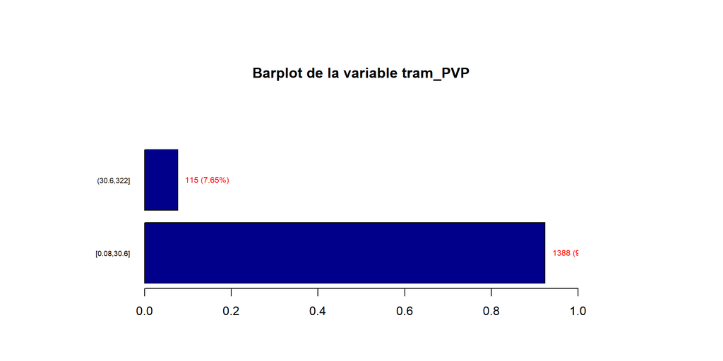

Descriptivo univariante para la variable tram_presentacion Variables Conteo Porcentaje 1 BLISTER 148 9.85 2 ENVASES 1129 75.12 3 FRASCOS 111 7.39 4 INHALADORES/OTROS 14 0.93 5 INJECTABLES 34 2.26 6 SOBRES 67 4.46

===============================

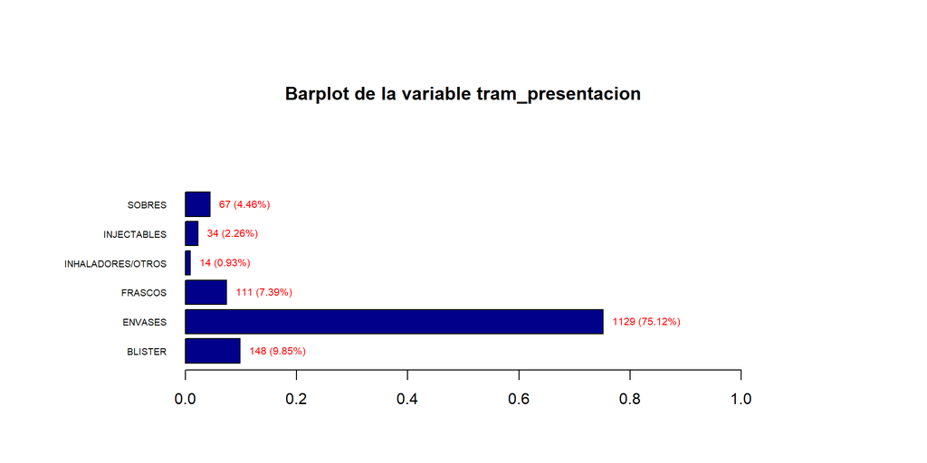

Descriptivo univariante para la variable Baja Variables Conteo Porcentaje 1 NO 1277 84.96 2 SI 226 15.04

===============================

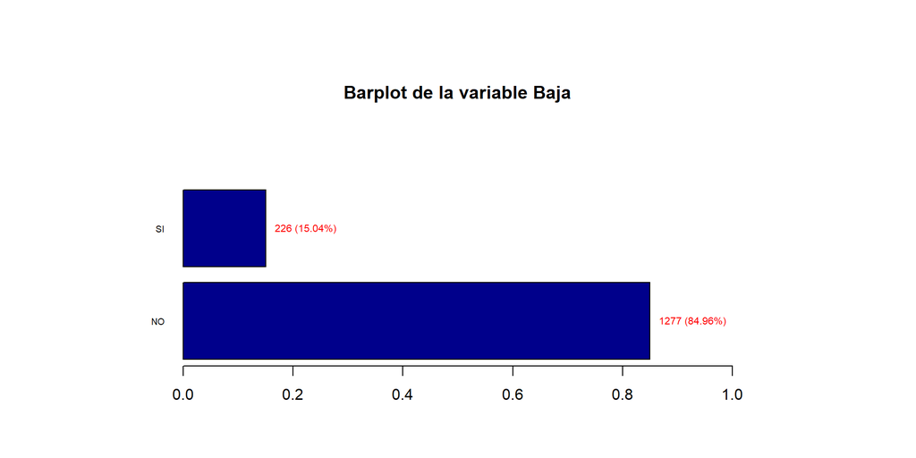

Descriptivo univariante para la variable Sociedad Variables Conteo Porcentaje 1 S.A. 643 42.78 2 S.A.U. 101 6.72 3 S.L. 538 35.80 4 S.L.U. 162 10.78 5 Sin sociedad 59 3.93

===============================

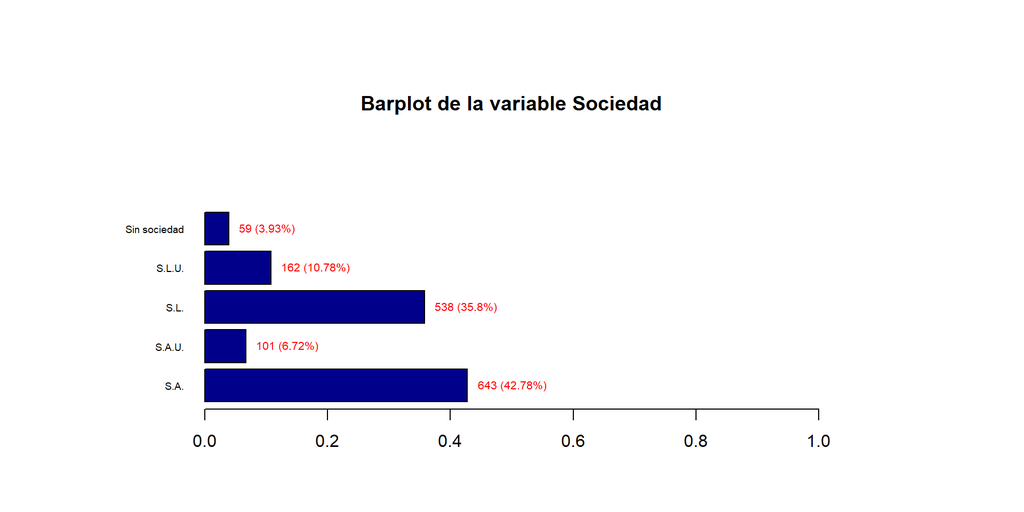

Como comprobamos, tenemos unos grupos realmente distribuidos y con los que podemos trabajar para realizar predicciones. Por lo tanto según nuestros boxplots, estas nuevas variables son suficientemente representativas para poder hacer uso de ellas.

## 5.2 Seleccion de las variables

A continuación se detallará que variables del dataset se descartará y cuales son los motivos que nos hacen descartar las variables. Estas variables son: - `Medicamento`: Es el nombre del medicamento y por lo tanto no lo necesitamos para generar modelos ya que sólo lo necesitamos para identifcar cada registro. - `URL`: Es una variable que enlaza cada url del vademecum con el registro del medicamento. - `Precio_Referencia`: Descartamos esta variable ya que detectamos que tenian NA’s y que era igual que la variable `PVP` al tener correlación de 1. - `Fecha_Alta`: Descartamos la variable ya que no trabajaremos con fechas de introducción de la información en la base de datos ya que no nos aporta información. - `Fecha_Baja`: Descartamos la variable ya que no nos aporta información. - `Menor_Precio_Agrupacion_Homogenea`: Descartamos esta variable ya que detectamos que tenian NA’s y que era igual que la variable `PVP` al tener correlación de 1. - `Generico`: Eliminamos esta variable ya que no tiene información (es toda NA’s) - `Presentacion`: Escogemos la variable creada `tram_presentacion` en lugar de presentación para evitar tener una variable con muchas categorias. - `Agrupacion_Homogenea`: Escogemos la variable creada `Codigo_Agrupacion` en su defecto para evitar que hayan posible problemas en la unificación de categorias escritas de diferentes formas. - `Laboratorio`: Escogemos la variable creada `Codigo_Laboratorio` en su defecto para evitar que hayan posible problemas en la unificación de categorias escritas de diferentes formas.

```r
cols <- c("Tipo", "Codigo_Laboratorio", "Estado", "Baja", "Aportacion_Beneficiario", "Principio_Activo", "PVP", "tram_PVP", "Tratamiento_Larga_Duracion", "Enfermedad", "tram_presentacion", "Sociedad", "Codigo_Agrupacion")

datos_sel <- datos[, cols]
```

## 5.3 Imputación de variables

En este apartado no deberemos imputar nada debido a que las variables numéricas seleccionadas, no se han de imputar, ya que son completas. Las variables descartadas eran las únicas que contenian NA’s y que deberiamos de haber imputado pero no las hemos cogido para hacer los modelos ya que anteriormente hemos visto que las correlaciones entre `PVP` y las otras dos era perfecta ($\rho = 1$). Por lo tanto, si se hubiera necesitado imputar los valores lo hubieramos hecho a través de paquetes que tuvieran en cuenta la distribución de las variables informadas.

## 5.4 Ceros y elementos vacíos

Tal y como se explica en el apartado anterior, al haber seleccionado algunas variables hemos hecho que tuvieramos menos casos a tener en cuenta como ceros y elementos vacíos. Por lo tanto a continuación vamos a generar una tabla para identificar los NA’s correspondientes para cada variable y veremos como cambiaremos estos NA’s.

```r
NAs <- data.frame(absoluto = colSums(is.na(datos_sel)))
NAs[, 'porcentaje'] <- round((NAs$absoluto/nrow(datos_sel))*100, 2)
NAs
```

|  | absoluto | porcentaje |
| --- | --- | --- |
| Tipo | 0 | 0 |
| Codigo_Laboratorio | 0 | 0 |
| Estado | 0 | 0 |
| Baja | 0 | 0 |
| Aportacion_Beneficiario | 0 | 0 |
| Principio_Activo | 0 | 0 |
| PVP | 0 | 0 |
| tram_PVP | 0 | 0 |
| Tratamiento_Larga_Duracion | 0 | 0 |
| Enfermedad | 0 | 0 |

[output cut: 3 more lines]

Vemos como obtenemos un 5% de valores perdidos en la variable `Agrupacion_Homogenea` y la variable que deriva de ella `Codigo_Agrupacion`. Por lo tanto deberemos de tratarla para que desaparezcan este porcentaje de NA’s.

Para ello crearemos una nueva categoria de la variable que sea `99999`. Este codigo lo que nos estará diciendo es que será una nueva variable que la llamaremos SIN AGRUPACIÓN.

```r
qui <- which(is.na(datos_sel[, 'Codigo_Agrupacion']))
datos_sel[qui, 'Codigo_Agrupacion'] <- '99999'
```

Volvemos a examinar el número de NA’s que contienen en nuestros datos y observaremos como ya no tenemos NA’s en ellos.

```r
NAs <- data.frame(absoluto = colSums(is.na(datos_sel)))
NAs[, 'porcentaje'] <- round((NAs$absoluto/nrow(datos_sel))*100, 2)
NAs
```

|  | absoluto | porcentaje |
| --- | --- | --- |
| Tipo | 0 | 0 |
| Codigo_Laboratorio | 0 | 0 |
| Estado | 0 | 0 |
| Baja | 0 | 0 |
| Aportacion_Beneficiario | 0 | 0 |
| Principio_Activo | 0 | 0 |
| PVP | 0 | 0 |
| tram_PVP | 0 | 0 |
| Tratamiento_Larga_Duracion | 0 | 0 |
| Enfermedad | 0 | 0 |

[output cut: 3 more lines]

## 5.5 Normalidad de las variables

A continuación vamos a analizar si nuestra variable `PVP` sigue una distribución normal o por el contrario no la sigue y deberemos de hacer tansformaciones.

Primero de todo vamos a visualizar los gráficos para ver si realmente son normales.

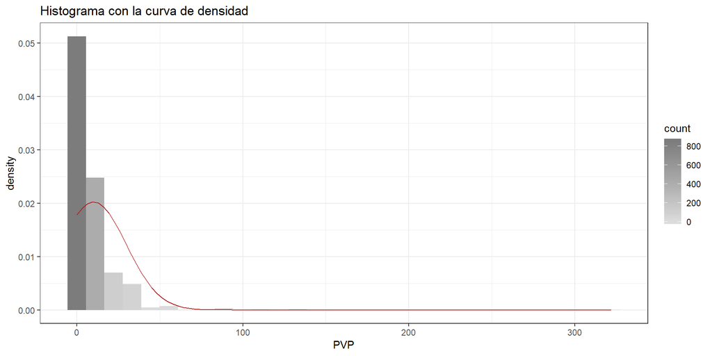

```r
library(ggplot2)

par(mfrow = c(1, 2))
ggplot(data = datos_sel, aes(x = PVP)) +
  geom_histogram(aes(y = ..density.., fill = ..count..)) +
  scale_fill_gradient(low = "#DCDCDC", high = "#7C7C7C") +
  stat_function(fun = dnorm, colour = "firebrick",
                args = list(mean = mean(datos_sel$PVP),
                            sd = sd(datos_sel$PVP))) +
  ggtitle("Histograma con la curva de densidad") +
  theme_bw()
```

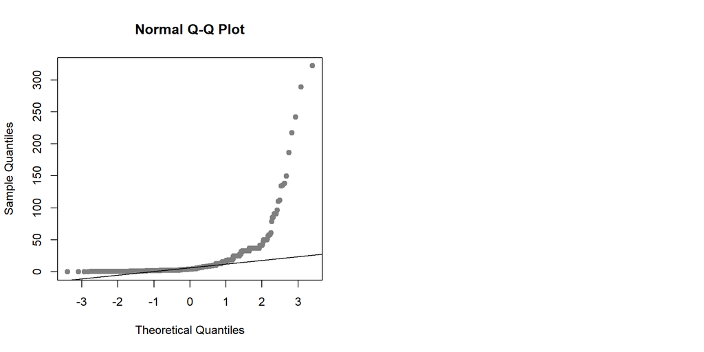

```r
qqnorm(datos_sel$PVP, pch = 19, col = "gray50")
qqline(datos_sel$PVP)
par(mfrow = c(1, 1))
```

Vemos como realmente nos está hablando de que nuestros datos no son normales ya que los puntos no se distributen encima de la linia y el histograma nos informa de que su forma distribuida podria ser como una $\chi^2$.

Vamos a comprobar lo que nos dice los gráficos mediante dos contrastes estadísticos:

```r
print(shapiro.test(x = datos_sel$PVP))
```

```
Shapiro-Wilk normality test
```

data: datos_sel$PVP W = 0.39369, p-value < 0.00000000000000022

```r
print(ks.test(x = datos_sel$PVP, "pnorm", mean(datos_sel$PVP), sd(datos_sel$PVP)))
```

```
One-sample Kolmogorov-Smirnov test
```

data: datos_sel$PVP D = 0.31395, p-value < 0.00000000000000022 alternative hypothesis: two-sided

```r
library("nortest")
lillie.test(x = datos_sel$PVP)
```

```
Lilliefors (Kolmogorov-Smirnov) normality test
```

data: datos_sel$PVP D = 0.31395, p-value < 0.00000000000000022

```r
library("tseries")
jarque.bera.test(x = datos_sel$PVP)
```

```
Jarque Bera Test
```

data: datos_sel$PVP X-squared = 621120, df = 2, p-value < 0.00000000000000022

Como podemos comporbar ninguno de los cuatro tests de comprobación de normalidad nos indica que nuestros datos se distribuyan de forma normal. (Generamos 4 contrastes diferentes ya que cada uno de ellos se pueden considerar mas o menos restrictivos a la hora de calcular la normalidad).

Por lo tanto los constrastes nos están indicando que no existe normalidad en los datos.

A continuación realizaremos una transformación logarítmica a ver si corregimos el efecto del sesgo relacionado con el precio.

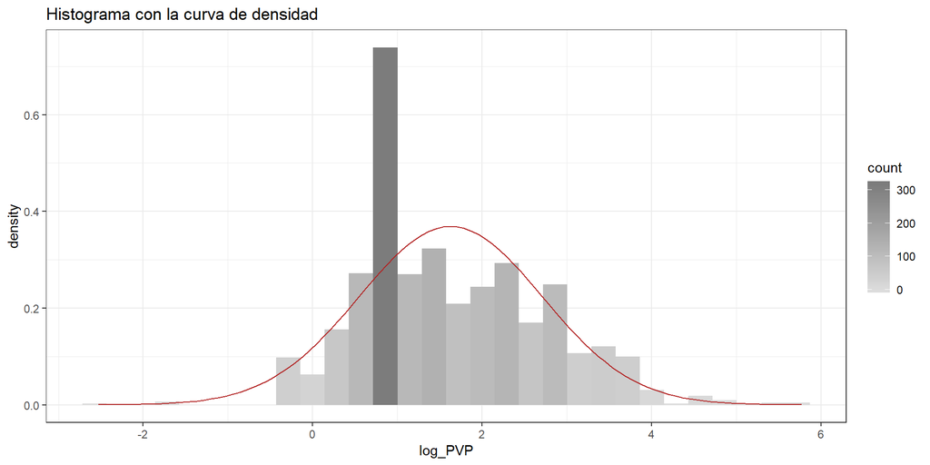

```r
datos_sel$log_PVP <- log(datos_sel$PVP)
library(ggplot2)

par(mfrow = c(1, 2))
ggplot(data = datos_sel, aes(x = log_PVP)) +
  geom_histogram(aes(y = ..density.., fill = ..count..)) +
  scale_fill_gradient(low = "#DCDCDC", high = "#7C7C7C") +
  stat_function(fun = dnorm, colour = "firebrick",
                args = list(mean = mean(datos_sel$log_PVP),
                            sd = sd(datos_sel$log_PVP))) +
  ggtitle("Histograma con la curva de densidad") +
  theme_bw()
```

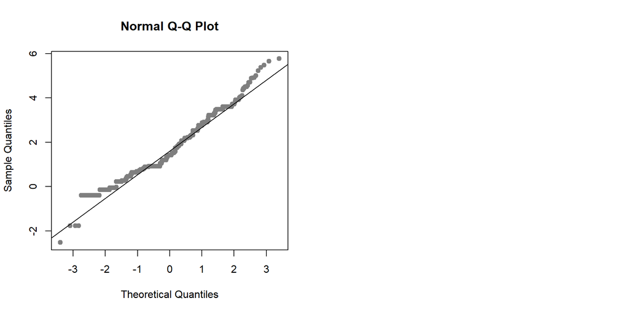

```r
qqnorm(datos_sel$log_PVP, pch = 19, col = "gray50")
qqline(datos_sel$log_PVP)
par(mfrow = c(1, 1))
```

A simple vista y tal y como nos muestra los gráficos podemos ver que los datos han sido normalizados excepto en una pequeña porporcion de ellos entorno al 1. Vamos a aplicar los contrastes a ver si nos verifican realmente que existe normalidad una vez realizado el logaritmo.

```r
shapiro.test(x = datos_sel$log_PVP)
```

```
Shapiro-Wilk normality test
```

data: datos_sel$log_PVP W = 0.96795, p-value < 0.00000000000000022

```r
ks.test(x = datos_sel$log_PVP, "pnorm", mean(datos_sel$log_PVP), sd(datos_sel$log_PVP))
```

```
One-sample Kolmogorov-Smirnov test
```

data: datos_sel$log_PVP D = 0.12554, p-value < 0.00000000000000022 alternative hypothesis: two-sided

```r
library("nortest")
lillie.test(x = datos_sel$log_PVP)
```

```
Lilliefors (Kolmogorov-Smirnov) normality test
```

data: datos_sel$log_PVP D = 0.12554, p-value < 0.00000000000000022

```r
library("tseries")
jarque.bera.test(x = datos_sel$log_PVP)
```

```
Jarque Bera Test
```

data: datos_sel$log_PVP X-squared = 60.764, df = 2, p-value = 0.00000000000006384

```r
# Eliminamos los valores que no queremos
datos_sel$log_PVP <- NULL
```

Aunque visualmente veíamos una corrección en los datos a normales, hemos podido comprobar que tampoco conseguimos que sea normal. Nos replanteamos la idea de hacer la misma prueba para la raíz cuadrada y seguiamos considerando NO normalidad de los datos. Para acabar el proceso intentamos realizar los mismos pasos pero agrupando en baratos y caros y nos continuaba saliendo que no exisita normalidad en nuestros datos.

En definitiva, trabajaremos con la variable `PVP` aunque sepamos que no sigue una distribución normal. Esto pasa porque cuando se diseño el experimento de extracción de la información se fue a coger directamente aquellos medicamentos contra la cura de enfermedades importantes y además aquellos medicamentos con más ingresos por parte de los laboratorios con su distribución. Por lo tanto entendemos perfectamente que los datos al final no se distribuyan como una normal.

Seguidamente comprobaremos como los constrastes nos hablaran realmente de que existe diferencias según el laboratorio, el tipo y otras características. Esto nos da mas motivos para pensar que el diseño de experimento fue erroneo y las consequencias han sido la de tener datos no normalizados.

Una posible solución de normalización de los datos sería realizando la estandarización por el máximo pero en este trabajo no hemos aprofundizado por esta via.

## 5.6 Detección de outliers

Para la detección de outliers vamos a trabajar con el contraste de Bonferonni y las distancias de Cook.

Primero de todo graficamos las distancias de Cook.

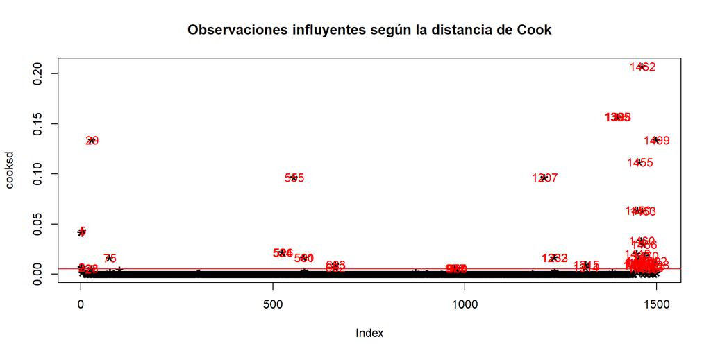

```r
modelo <- lm(PVP ~ ., data = datos_sel)
cooksd <- cooks.distance(modelo)
plot(cooksd, pch="*", cex=2, main="Observaciones influyentes según la distancia de Cook")
abline(h = 4*mean(cooksd, na.rm = T), col = "red")
text(x = 1:length(cooksd) + 1, y = cooksd, labels = ifelse(cooksd>4*mean(cooksd, na.rm = T),names(cooksd),""), col = "red")
```

Comprobamos como todos aquellos valores por encima de la línia roja se considerarán que son outliers. Y por lo tanto tenemos bastantes casos considerados outliers.

A continuación vamos a realiziar el test de Bonferonni para detectar los outliers que tensmo en nuestra base de datos.

```r
library(car)
outlierTest(modelo)
```

[output not shown]

Nosotros nos quedamos con esos valores ya que consideramos que han sido generados por un mal diseño experimental (ya que se han descargado medicamentos escogidos y no al azar).

# 6. Contrastes

Seguidamente vamos a realizar contraste de hipótesis para poder resolver algunas de las cuestiones que se planteaban en el objetivo de este informe.

## 6.1 Precio vs. Tipo de Medicamento

A continuación queremos ver si existen diferencias o no en el precio entre diferentes tipos de medicamentos.

#### Hipótesis nula y alternativa

- $H_{0}: \mu_{1} = \mu{2} = \mu_{3}$
- $H_{1}$: Las medias poblacionales de las muestras no son iguales

donde $\mu_{1}$ es el precio de medicamentos de tipo ‘Medicamento Etica’, $\mu{2}$ el precio de medicamentos de tipo ‘Medicamento Generico’ y $\mu_{3}$ el precio de medicamentos de tipo ‘Medicamento con Denominacion Generica’.

#### Resolución

```r
kruskal.test(PVP ~ as.factor(Tipo), data = datos)
```

```
Kruskal-Wallis rank sum test
```

data: PVP by as.factor(Tipo) Kruskal-Wallis chi-squared = 30.978, df = 2, p-value = 0.0000001876

Como observamos, la variable tipo es relevante a la hora de definir el precio del medicamento, por lo que rechazamos la hipótesis nula. Por lo tanto, podemos confirmar que existen diferencias en el precio según el tipo de medicamento.

## 6.2 Precio vs. Laboratorio

En este apartado buscamos ver si existen diferencias en el precio del medicamento dependiendo de que laboratorio ha generado el medicamento.

#### Hipótesis nula y alternativa

- $H_{0}: \mu_{1} = \mu{2} = ... = \mu{n}$
- $H_{1}$: Las medias poblacionales de las muestras no son iguales

donde μ representa los precios de los distintos laboratorios.

#### Resolución

Aplicaremos un test no paramétrico, el test Kruskal-Wallis, equivalente a ANOVA.

```r
kruskal.test(PVP ~ as.factor(Laboratorio), data = datos)
```

```
Kruskal-Wallis rank sum test
```

data: PVP by as.factor(Laboratorio) Kruskal-Wallis chi-squared = 233.41, df = 72, p-value < 0.00000000000000022

Como el p-value obtenido es menos de 0.001, sabemos que las modificaciones que la variable Laboratorio obtiene son relevantes en cuanto al PVP. Por lo tanto, tal y como en el ejercicio anterior, rechazamos la hipótesis nula. Esto quiere decir que el precio del medicamento es influido por el laboratorio que lo genera.

Nosotros tenemos la idea de que la variable Laboratorio no es realmente la que influya en el precio sinó en el hecho de que tenemos medicamentos para tratamientos muy específicos asociados a laboratorios muy específicos y por lo tanto este hecho hace que haya confusión entre variables.

## 6.3 Precio vs. Enfermedad

En este último contraste la idea que queremos plasmar es el hecho de si existe o no existe diferencias en el precio del medicamento según la enfermedad a la que se quiere combatir. Este contraste es un poco obvio pero nos sirve para validar si realmente nuestra base de datos tiene los supósitos de que medicamentos más caros serviran para atacar a enfermedades diferentes.

#### Hipótesis nula y alternativa

- $H_{0}: \mu_{1} = \mu{2} = ... = \mu{n}$
- $H_{1}$: Las medias poblacionales de las muestras no son iguales

donde μ representa los precios de las distintas enfermedades relacionadas.

#### Resolución

Aplicamos de nuevo el test Kruskal-Wallis:

```r
kruskal.test(PVP ~ as.factor(Enfermedad), data = datos)
```

```
Kruskal-Wallis rank sum test
```

data: PVP by as.factor(Enfermedad) Kruskal-Wallis chi-squared = 498.98, df = 12, p-value < 0.00000000000000022

Como en el caso anterior, al obtener un p-value menor que 0.001, sabemos que las modificaciones que la variable Enfermedad obtiene son relevantes en cuanto al PVP. Rechazamos la hipótesis nula, esto quiere decir que la enfermedad es influyente respecto al precio.

Esta conclusión ya la teniamos presente ya que tenemos medicamentos que sirven para paliar enfermedades crónicas graves y luego también tenemos medicamentos que sirven para tratar enfermedades como dolor de cabeza.

# 7. Predicciones

En este apartado lo que se va a intentar es utilizar diferentes herramientas de predicción o de agrupación automática para sacar conclusiones de patrones subyacentes en nuestros datos que hayamos sido incapaces de detectar mediante las descriptiva univariante y bivariante. Para ello hemos escogido un método de predicción lineal y posteriormente dos métodos no supervisados: Clusterización jerárquica (para agrupar medicamentos con las mismas características) y Análisis de Corrrespondéncias Múltiples (ACM) (para detectar patrones de similitud de casos a través de correlaciones de variables).

Para ello en cada apartado se explicará el uso de cada método de predicción.

## 7.1 Regressión lineal

A continuación vamos a modelar una regresión lineal para poder identificar cuales són aquellas variables importantes que nos ayudan a predecir el valor del precio.

Para ello estamos suponiendo que nuestros datos vienen distribuidos por una distribución normal que ya hemos demostrado anteriormente que no es correcto.

```r
# A continuación generamos nuestro modelo lineal. Para ello primero de todo vamos a hacer los pasos de stepwise para que se escojan automaticamente aquellas variables que sean importantes para el modelo.
library(MASS)

cols <- c("tram_PVP", "Codigo_Agrupacion")
dataRegresion <- datos_sel[, which(!colnames(datos_sel) %in% cols)]

full.model <- lm(PVP ~ ., data = dataRegresion)
step.model <- stepAIC(full.model, direction = "both", trace = FALSE)

summary(step.model)
```

Call: lm(formula = PVP ~ Tipo + Principio_Activo + log_PVP, data = dataRegresion)

Residuals: Min 1Q Median 3Q Max -82.230 -2.914 -0.199 2.349 183.578

Coefficients: Estimate (Intercept) -3.53828 TipoEtica -5.01419 TipoGenerico -1.24985 Principio_ActivoACETILSALICILICO ACIDO -0.81538 Principio_ActivoALENDRONATO SODIO COLECALCIFEROL -15.91851 Principio_ActivoALENDRONATO SODIO MONOHIDRATO COLECALCIFEROL -12.15417 Principio_ActivoALENDRONATO SODIO TRIHIDRATO COLECALCIFEROL -15.91851 Principio_ActivoALENDRONICO ACIDO COLECALCIFEROL -15.91851 Principio_ActivoALPRAZOLAM -4.76017 Principio_ActivoAMLODIPINO BESILATO ATORVASTATINA CALCICA TRIHIDRATO -16.54735 Principio_ActivoAMOXICILINA -5.69631 Principio_ActivoAMOXICILINA CLAVULANICO ACIDO -14.00499 Principio_ActivoAMOXICILINA TRIHIDRATO -7.37286 Principio_ActivoAMOXICILINA TRIHIDRATO CLAVULANATO POTASIO -13.75001 Principio_ActivoAMOXICILINA TRIHIDRATO CLAVULANICO ACIDO -13.68302 Principio_ActivoAPIXABAN 23.76833 Principio_ActivoATORVASTATINA -11.98493 Principio_ActivoATORVASTATINA CALCICA -12.31098 Principio_ActivoATORVASTATINA CALCICA TRIHIDRATO -12.23614 Principio_ActivoCALCIO CARBONATO COLECALCIFEROL -14.44259 Principio_ActivoDEXKETOPROFENO -4.80473 Principio_ActivoDEXKETOPROFENO TROMETAMOL -7.44723 Principio_ActivoENOXAPARINA SODICA 69.57966 Principio_ActivoESOMEPRAZOL -14.93067 Principio_ActivoESOMEPRAZOL MAGNESICO -14.20698 Principio_ActivoESOMEPRAZOL MAGNESICO DIHIDRATO -13.55568 Principio_ActivoESOMEPRAZOL SODICO -13.49395 Principio_ActivoFLUTICASONA PROPIONATO SALMETEROL XINAFOATO 0.03697 Principio_ActivoFUROSEMIDA -2.34469 Principio_ActivoHIDROCLOROTIAZIDA RAMIPRIL -11.25065 Principio_ActivoIBUPROFENO -2.63315 Principio_ActivoIBUPROFENO ARGININA -4.97599 Principio_ActivoINSULINA ASPARTA -1.62190 Principio_ActivoINSULINA GLARGINA 7.37337 Principio_ActivoLANSOPRAZOL -15.07455 Principio_ActivoLEVOTIROXINA SODICA -7.34377 Principio_ActivoLIRAGLUTIDA 80.74800 Principio_ActivoLORAZEPAM 4.36129 Principio_ActivoMETAMIZOL MAGNESICO 2.02988 Principio_ActivoMETFORMINA HIDROCLORURO SITAGLIPTINA FOSFATO MONOHIDRATO 14.67874 Principio_ActivoOMEPRAZOL -4.42171 Principio_ActivoPARACETAMOL -0.17924 Principio_ActivoPARACETAMOL CODEINA -4.25074 Principio_ActivoPARACETAMOL CODEINA FOSFATO -1.21165 Principio_ActivoPARACETAMOL CODEINA FOSFATO HEMIHIDRATO -4.25074 Principio_ActivoPARACETAMOL TRAMADOL HIDROCLORURO -10.87981 Principio_ActivoPREGABALINA -3.74964 Principio_ActivoRAMIPRIL -11.36912 Principio_ActivoRIVAROXABAN 25.02252 Principio_ActivoSALBUTAMOL -0.62204 Principio_ActivoSALBUTAMOL SULFATO -1.72862 Principio_ActivoSIMVASTATINA 0.77185 Principio_ActivoSIMVASTATINA EZETIMIBA -9.17692 Principio_ActivoSITAGLIPTINA -10.41683 Principio_ActivoSITAGLIPTINA FOSFATO MONOHIDRATO 33.97327 log_PVP 13.38453 Std. Error (Intercept) 8.13893 TipoEtica 3.62771 TipoGenerico 3.49831 Principio_ActivoACETILSALICILICO ACIDO 9.48008 Principio_ActivoALENDRONATO SODIO COLECALCIFEROL 10.46148 Principio_ActivoALENDRONATO SODIO MONOHIDRATO COLECALCIFEROL 8.99783 Principio_ActivoALENDRONATO SODIO TRIHIDRATO COLECALCIFEROL 8.45428 Principio_ActivoALENDRONICO ACIDO COLECALCIFEROL 9.10303 Principio_ActivoALPRAZOLAM 7.87954 Principio_ActivoAMLODIPINO BESILATO ATORVASTATINA CALCICA TRIHIDRATO 9.08018 Principio_ActivoAMOXICILINA 10.37779 Principio_ActivoAMOXICILINA CLAVULANICO ACIDO 8.18480 Principio_ActivoAMOXICILINA TRIHIDRATO 7.46698 Principio_ActivoAMOXICILINA TRIHIDRATO CLAVULANATO POTASIO 7.53253 Principio_ActivoAMOXICILINA TRIHIDRATO CLAVULANICO ACIDO 8.10997 Principio_ActivoAPIXABAN 9.57907 Principio_ActivoATORVASTATINA 8.09174 Principio_ActivoATORVASTATINA CALCICA 7.57161 Principio_ActivoATORVASTATINA CALCICA TRIHIDRATO 7.54753 Principio_ActivoCALCIO CARBONATO COLECALCIFEROL 10.40916 Principio_ActivoDEXKETOPROFENO 8.93265 Principio_ActivoDEXKETOPROFENO TROMETAMOL 10.31830 Principio_ActivoENOXAPARINA SODICA 7.90425 Principio_ActivoESOMEPRAZOL 8.58322 Principio_ActivoESOMEPRAZOL MAGNESICO 7.57698 Principio_ActivoESOMEPRAZOL MAGNESICO DIHIDRATO 7.91309 Principio_ActivoESOMEPRAZOL SODICO 7.66705 Principio_ActivoFLUTICASONA PROPIONATO SALMETEROL XINAFOATO 8.56084 Principio_ActivoFUROSEMIDA 7.78230 Principio_ActivoHIDROCLOROTIAZIDA RAMIPRIL 8.52000 Principio_ActivoIBUPROFENO 7.51077 Principio_ActivoIBUPROFENO ARGININA 7.73534 Principio_ActivoINSULINA ASPARTA 9.52865 Principio_ActivoINSULINA GLARGINA 9.55767 Principio_ActivoLANSOPRAZOL 7.52874 Principio_ActivoLEVOTIROXINA SODICA 7.93626 Principio_ActivoLIRAGLUTIDA 12.81794 Principio_ActivoLORAZEPAM 10.31265 Principio_ActivoMETAMIZOL MAGNESICO 10.31109 Principio_ActivoMETFORMINA HIDROCLORURO SITAGLIPTINA FOSFATO MONOHIDRATO 12.75055 Principio_ActivoOMEPRAZOL 7.36986 Principio_ActivoPARACETAMOL 7.40491 Principio_ActivoPARACETAMOL CODEINA 10.37563 Principio_ActivoPARACETAMOL CODEINA FOSFATO 10.31081 Principio_ActivoPARACETAMOL CODEINA FOSFATO HEMIHIDRATO 9.00424 Principio_ActivoPARACETAMOL TRAMADOL HIDROCLORURO 7.44279 Principio_ActivoPREGABALINA 9.00099 Principio_ActivoRAMIPRIL 7.55690 Principio_ActivoRIVAROXABAN 9.11092 Principio_ActivoSALBUTAMOL 8.92933 Principio_ActivoSALBUTAMOL SULFATO 8.93429 Principio_ActivoSIMVASTATINA 7.46053 Principio_ActivoSIMVASTATINA EZETIMIBA 7.76575 Principio_ActivoSITAGLIPTINA 10.37584 Principio_ActivoSITAGLIPTINA FOSFATO MONOHIDRATO 10.48450 log_PVP 0.53384 t value (Intercept) -0.435 TipoEtica -1.382 TipoGenerico -0.357 Principio_ActivoACETILSALICILICO ACIDO -0.086 Principio_ActivoALENDRONATO SODIO COLECALCIFEROL -1.522 Principio_ActivoALENDRONATO SODIO MONOHIDRATO COLECALCIFEROL -1.351 Principio_ActivoALENDRONATO SODIO TRIHIDRATO COLECALCIFEROL -1.883 Principio_ActivoALENDRONICO ACIDO COLECALCIFEROL -1.749 Principio_ActivoALPRAZOLAM -0.604 Principio_ActivoAMLODIPINO BESILATO ATORVASTATINA CALCICA TRIHIDRATO -1.822 Principio_ActivoAMOXICILINA -0.549 Principio_ActivoAMOXICILINA CLAVULANICO ACIDO -1.711 Principio_ActivoAMOXICILINA TRIHIDRATO -0.987 Principio_ActivoAMOXICILINA TRIHIDRATO CLAVULANATO POTASIO -1.825 Principio_ActivoAMOXICILINA TRIHIDRATO CLAVULANICO ACIDO -1.687 Principio_ActivoAPIXABAN 2.481 Principio_ActivoATORVASTATINA -1.481 Principio_ActivoATORVASTATINA CALCICA -1.626 Principio_ActivoATORVASTATINA CALCICA TRIHIDRATO -1.621 Principio_ActivoCALCIO CARBONATO COLECALCIFEROL -1.387 Principio_ActivoDEXKETOPROFENO -0.538 Principio_ActivoDEXKETOPROFENO TROMETAMOL -0.722 Principio_ActivoENOXAPARINA SODICA 8.803 Principio_ActivoESOMEPRAZOL -1.740 Principio_ActivoESOMEPRAZOL MAGNESICO -1.875 Principio_ActivoESOMEPRAZOL MAGNESICO DIHIDRATO -1.713 Principio_ActivoESOMEPRAZOL SODICO -1.760 Principio_ActivoFLUTICASONA PROPIONATO SALMETEROL XINAFOATO 0.004 Principio_ActivoFUROSEMIDA -0.301 Principio_ActivoHIDROCLOROTIAZIDA RAMIPRIL -1.320 Principio_ActivoIBUPROFENO -0.351 Principio_ActivoIBUPROFENO ARGININA -0.643 Principio_ActivoINSULINA ASPARTA -0.170 Principio_ActivoINSULINA GLARGINA 0.771 Principio_ActivoLANSOPRAZOL -2.002 Principio_ActivoLEVOTIROXINA SODICA -0.925 Principio_ActivoLIRAGLUTIDA 6.300 Principio_ActivoLORAZEPAM 0.423 Principio_ActivoMETAMIZOL MAGNESICO 0.197 Principio_ActivoMETFORMINA HIDROCLORURO SITAGLIPTINA FOSFATO MONOHIDRATO 1.151 Principio_ActivoOMEPRAZOL -0.600 Principio_ActivoPARACETAMOL -0.024 Principio_ActivoPARACETAMOL CODEINA -0.410 Principio_ActivoPARACETAMOL CODEINA FOSFATO -0.118 Principio_ActivoPARACETAMOL CODEINA FOSFATO HEMIHIDRATO -0.472 Principio_ActivoPARACETAMOL TRAMADOL HIDROCLORURO -1.462 Principio_ActivoPREGABALINA -0.417 Principio_ActivoRAMIPRIL -1.504 Principio_ActivoRIVAROXABAN 2.746 Principio_ActivoSALBUTAMOL -0.070 Principio_ActivoSALBUTAMOL SULFATO -0.193 Principio_ActivoSIMVASTATINA 0.103 Principio_ActivoSIMVASTATINA EZETIMIBA -1.182 Principio_ActivoSITAGLIPTINA -1.004 Principio_ActivoSITAGLIPTINA FOSFATO MONOHIDRATO 3.240 log_PVP 25.072 Pr(>|t|) (Intercept) 0.66382 TipoEtica 0.16713 TipoGenerico 0.72094 Principio_ActivoACETILSALICILICO ACIDO 0.93147 Principio_ActivoALENDRONATO SODIO COLECALCIFEROL 0.12832 Principio_ActivoALENDRONATO SODIO MONOHIDRATO COLECALCIFEROL 0.17697 Principio_ActivoALENDRONATO SODIO TRIHIDRATO COLECALCIFEROL 0.05992 Principio_ActivoALENDRONICO ACIDO COLECALCIFEROL 0.08055 Principio_ActivoALPRAZOLAM 0.54586 Principio_ActivoAMLODIPINO BESILATO ATORVASTATINA CALCICA TRIHIDRATO 0.06861 Principio_ActivoAMOXICILINA 0.58316 Principio_ActivoAMOXICILINA CLAVULANICO ACIDO 0.08728 Principio_ActivoAMOXICILINA TRIHIDRATO 0.32361 Principio_ActivoAMOXICILINA TRIHIDRATO CLAVULANATO POTASIO 0.06814 Principio_ActivoAMOXICILINA TRIHIDRATO CLAVULANICO ACIDO 0.09178 Principio_ActivoAPIXABAN 0.01320 Principio_ActivoATORVASTATINA 0.13879 Principio_ActivoATORVASTATINA CALCICA 0.10418 Principio_ActivoATORVASTATINA CALCICA TRIHIDRATO 0.10519 Principio_ActivoCALCIO CARBONATO COLECALCIFEROL 0.16551 Principio_ActivoDEXKETOPROFENO 0.59074 Principio_ActivoDEXKETOPROFENO TROMETAMOL 0.47057 Principio_ActivoENOXAPARINA SODICA < 0.0000000000000002 Principio_ActivoESOMEPRAZOL 0.08216 Principio_ActivoESOMEPRAZOL MAGNESICO 0.06099 Principio_ActivoESOMEPRAZOL MAGNESICO DIHIDRATO 0.08691 Principio_ActivoESOMEPRAZOL SODICO 0.07862 Principio_ActivoFLUTICASONA PROPIONATO SALMETEROL XINAFOATO 0.99656 Principio_ActivoFUROSEMIDA 0.76324 Principio_ActivoHIDROCLOROTIAZIDA RAMIPRIL 0.18688 Principio_ActivoIBUPROFENO 0.72595 Principio_ActivoIBUPROFENO ARGININA 0.52014 Principio_ActivoINSULINA ASPARTA 0.86487 Principio_ActivoINSULINA GLARGINA 0.44056 Principio_ActivoLANSOPRAZOL 0.04544 Principio_ActivoLEVOTIROXINA SODICA 0.35494 Principio_ActivoLIRAGLUTIDA 0.000000000395 Principio_ActivoLORAZEPAM 0.67243 Principio_ActivoMETAMIZOL MAGNESICO 0.84396 Principio_ActivoMETFORMINA HIDROCLORURO SITAGLIPTINA FOSFATO MONOHIDRATO 0.24983 Principio_ActivoOMEPRAZOL 0.54862 Principio_ActivoPARACETAMOL 0.98069 Principio_ActivoPARACETAMOL CODEINA 0.68210 Principio_ActivoPARACETAMOL CODEINA FOSFATO 0.90647 Principio_ActivoPARACETAMOL CODEINA FOSFATO HEMIHIDRATO 0.63694 Principio_ActivoPARACETAMOL TRAMADOL HIDROCLORURO 0.14402 Principio_ActivoPREGABALINA 0.67705 Principio_ActivoRAMIPRIL 0.13268 Principio_ActivoRIVAROXABAN 0.00610 Principio_ActivoSALBUTAMOL 0.94447 Principio_ActivoSALBUTAMOL SULFATO 0.84661 Principio_ActivoSIMVASTATINA 0.91761 Principio_ActivoSIMVASTATINA EZETIMIBA 0.23751 Principio_ActivoSITAGLIPTINA 0.31557 Principio_ActivoSITAGLIPTINA FOSFATO MONOHIDRATO 0.00122 log_PVP < 0.0000000000000002

Residual standard error: 10.31 on 1447 degrees of freedom Multiple R-squared: 0.7364, Adjusted R-squared: 0.7264 F-statistic: 73.51 on 55 and 1447 DF, p-value: < 0.00000000000000022

## 7.2 Agrupación de medicamentos (clúster)

A continuación vamos a clasificar nuestros datos a través de un modelo de agrupación jerárquico como són los clústers. Los métodos jerárquicos aplican una descomposición jerárquica del conjunto de datos origen. A partir del conjunto de datos por separado, va agrupando los grupos similares hasta formar un único grupo. Lo bueno de este tipo de modelos es que se puede visualizar el árbol que se genera al formar los grupos y decidir el número de clases en las que se quiere partir los datos.

[figure not shown]

```r
library(dendextend)
library(magrittr)
library(cluster)

datos_cluster <- datos_sel[, which(!colnames(datos_sel) %in% c('log_PVP', 'PVP', 'Codigo_Agrupacion', 'Codigo_Laboratorio', 'Principio_Activo'))]

for(i in colnames(datos_cluster)){
  datos_cluster[, i] <- as.factor(datos_cluster[, i])
}

k = 4

dend <- datos_cluster %>% daisy(metric = "gower", stand=TRUE) %>% hclust(method="ward.D") %>% as.dendrogram

labels(dend) <- rep(NA,nrow(datos_cluster))

dend %>% color_branches(k=k ,col = rainbow(k)) %>% plot(horiz=FALSE, main = "Método de Ward: 3 clusters",xlab='Participantes',ylab='Distancias')

legend('topright',legend=c('Cluster 1','Cluster 2','Cluster 3', 'Cluster 4'), lty=rep(1,3), col=rainbow(k),cex=0.7)
abline(h = 33, lwd = 2, lty = 2, col = "blue")
```

```r
c1 <- cutree(dend, k)

datos_cluster$CLUST4 <- as.factor(c1)

# Como hemos visto en el gráfico tenemos outliers en diferentes grupos que no se clasifican correctamente, por ello vamos a incorporar esos valores en su cluster correspondiente
```

Como podemos ver en nuestro clúster, utilizamos la distancia de Gower ya que es aquella distancia que nos permite trabajar con variables de tipo categóricas. También se le aplica el método de Ward. El método de Ward es aquel que nos permite asegurar mínima variancia entre los grupos que se van formando.

En el gráfico podemos ver como podriamos formar 4 clases. El propósito era poder encontrar patrones de semejanza entre conjuntos de medicamentos y bajo una decisión experta, hemos decidido avanzar con el clúster de 4 clases.

A continuación se muestra una descriptiva de las clases para las variables que hemos escogido para poder hacer un perfil de lo que encontramos en cada clase obtenida. Como todos las variables que hemos utilizado para generar el clúster han sido categóricas vamos a realizar unos gráficos agrupados y posteriormente un contraste de chi2 para ver realmente si existe o no independencia entre las clases de clúster y las variables explicativas.

Así utilizando este procedimiento podemos ver de que variables definen nuestros grupos realizados por el clúster.

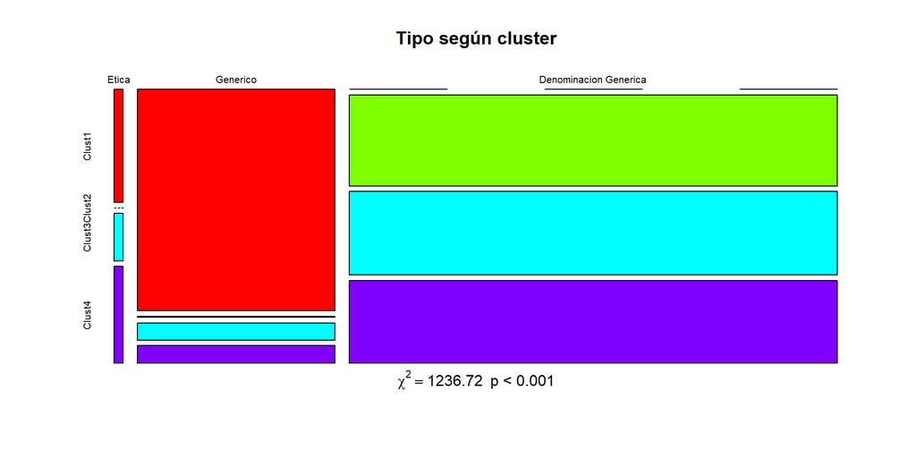

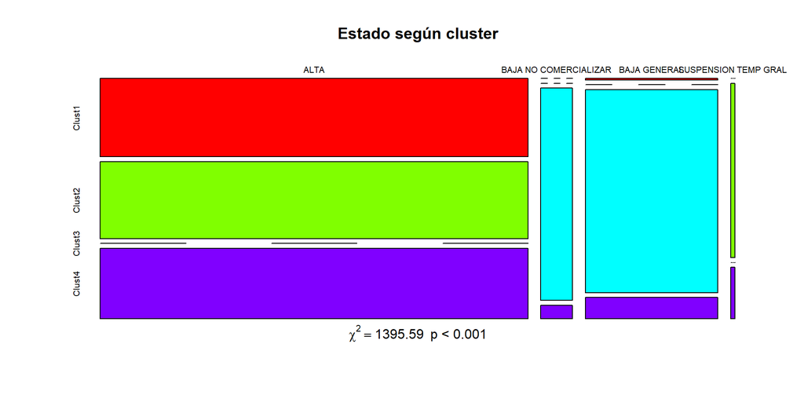

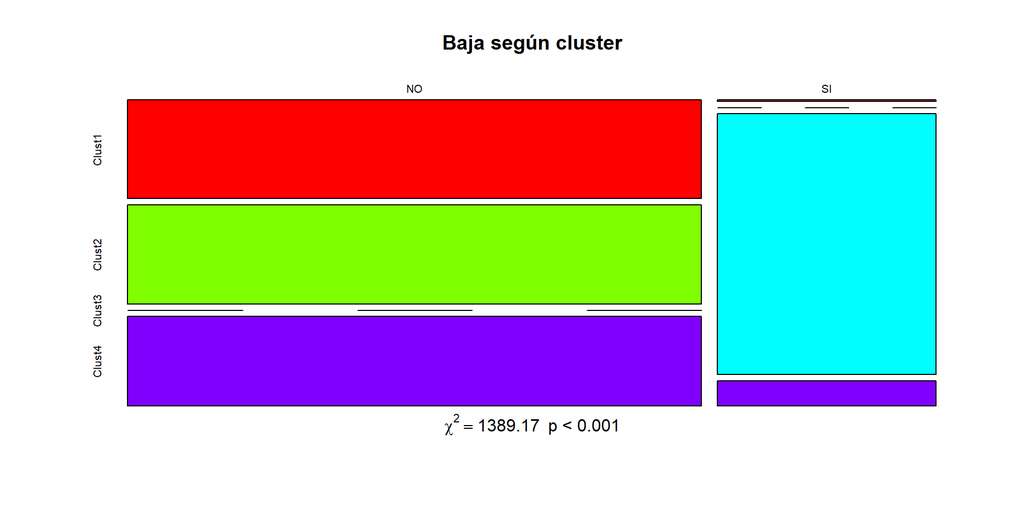

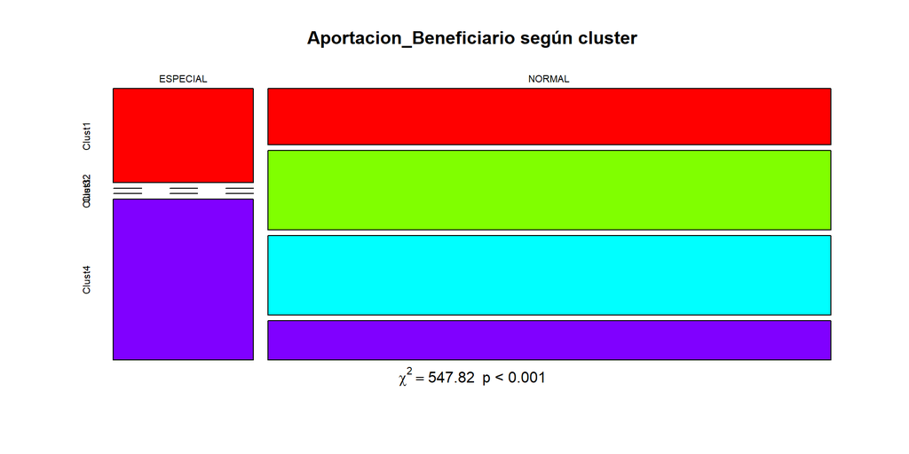

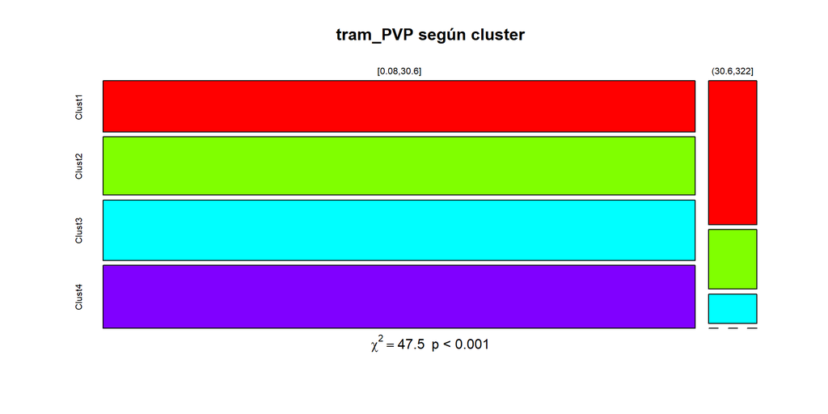

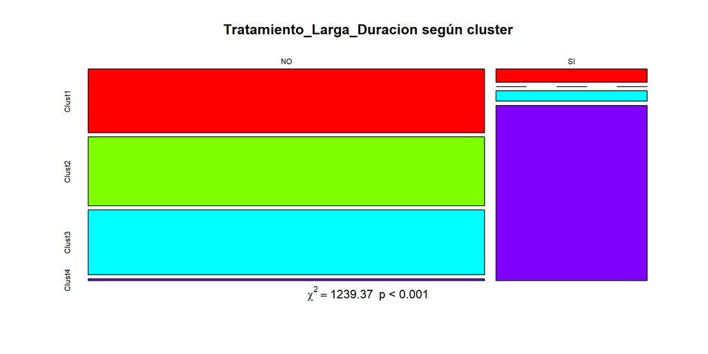

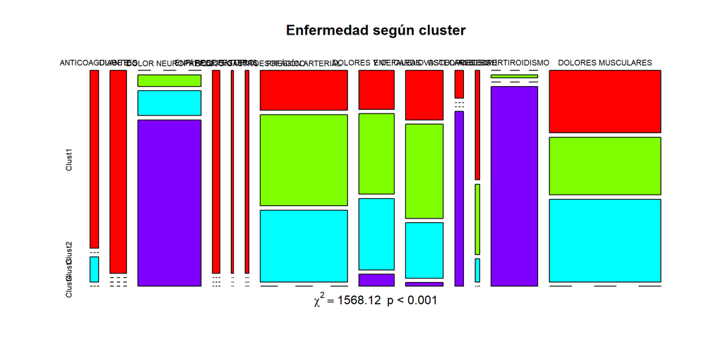

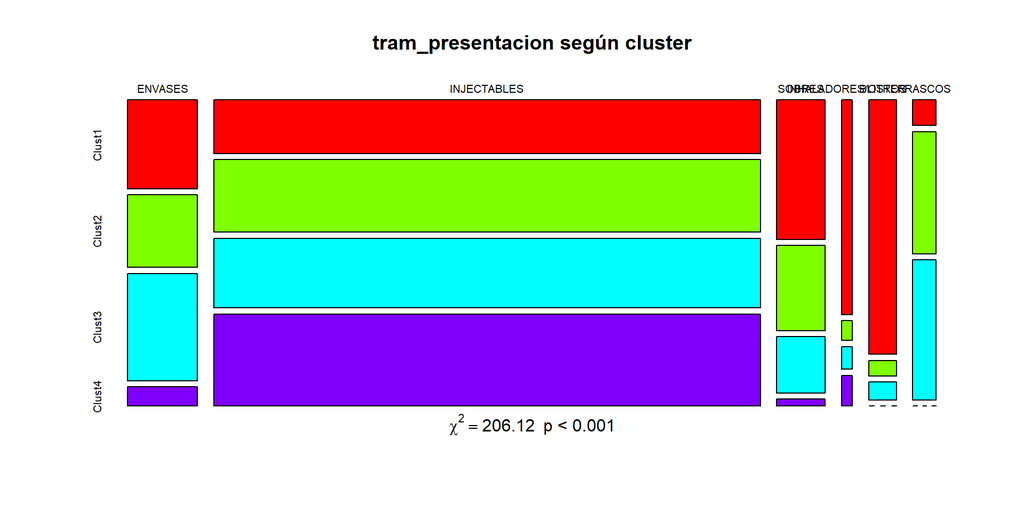

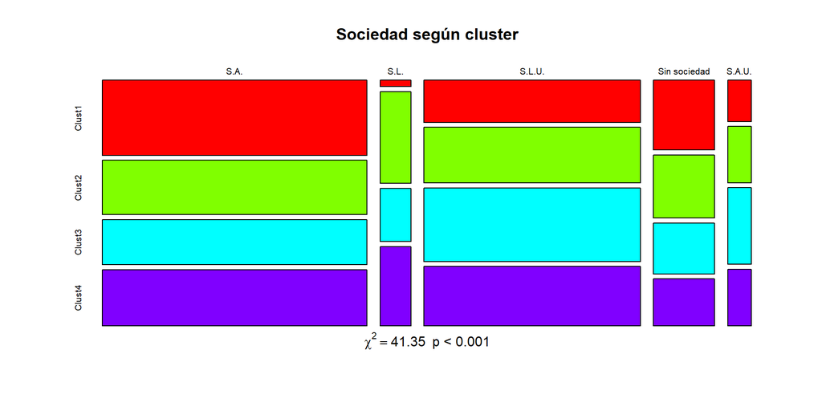

```r
cols <- colnames(datos_cluster)[-10]

for (col in cols){
  tabla <- prop.table(ftable(formula(paste0("CLUST4 ~ ", col)), datos_cluster), 2)
  lbls <- unique(datos[, col])
  dimnames(tabla) <- list(lbls, paste0("Clust", levels(datos_cluster$CLUST4)))
  mosaicplot(tabla,col=rainbow(4),main = paste0(col, " según cluster"))
  chisq.test(ftable(formula(paste0("CLUST4 ~ ", col)), datos_cluster))-> test
  p <- if(test$p.value>.001) {paste("p =",round(test$p.value,3))} else {"p < 0.001"}
  mtext(side=1,bquote(chi^2== .(round(test$statistic,2)) ~~ .(p)),padj=0.5)
}
```

## 7.3 Detección de patrones en las características (ACM)

Para acabar el tema de los modelos supervisados y no supervisados, hemos decidido generar un modelo de análisis de correspondencias múltiples (ACM). El análisis de correspondéncias múltiples (ACM) se trata de un método destinado a variables nominales que se utiliza para detectar y representar patrones escondidos en los datos.

La forma de proceder es la siguiente, se representa los datos como puntos en un espacio euclídeo de dimensión 2. La forma de proyección es la misma que se utilizaria para la creación de los ACP (Análisis de componentes princiales) peró con variables que tienen más de dos niveles en sus categorias.

Por lo tanto esta forma de detectar patrones es muy eficaz para nuestro conjunto de datos ya que, como se han explicado en apartados anteriores, nuestros datos estan compuestos por variables categóricas y una variable numérica.

```r
# install.packages("ade4", dep = TRUE)
library(ade4)

# Creamos los datos para el ACM descartando la variable numérica
datosACM <- datos_sel[, which(!colnames(datos_sel) %in% c('PVP', 'Codigo_Laboratorio', 'Codigo_Agrupacion', 'Principio_Activo'))]

for(i in colnames(datosACM)){
  datosACM[, i] <- as.factor(datosACM[, i])
}

# Generamos el modelo ACM
acm <- dudi.acm(datosACM, scannf = FALSE, nf = 10)

# Mostramos los gráficos
print(summary(acm))
```

Class: acm dudi Call: dudi.acm(df = datosACM, scannf = FALSE, nf = 10)

Total inertia: 3.333

Eigenvalues: Ax1 Ax2 Ax3 Ax4 Ax5 0.3088 0.2338 0.2149 0.1642 0.1607

Projected inertia (%): Ax1 Ax2 Ax3 Ax4 Ax5 9.265 7.013 6.447 4.925 4.822

Cumulative projected inertia (%): Ax1 Ax1:2 Ax1:3 Ax1:4 Ax1:5 9.265 16.278 22.725 27.650 32.473

(Only 5 dimensions (out of 29) are shown)

NULL

Hemos tenido que descartar algunas de las variables debido al gran volumen de categorias que tenian esas variables. De aquí deberemos extraer una de las posibles mejoras del trabajo que seria el hecho de agrupar mejor categorias ya que con tantas categorias, el ACM no es comprensible visualmente.

Teniendo en cuenta las limitaciones anteriores, vamos a interpretar tanto la salida de la inercia que contienen nuestros datos como la visualización de las categorias.

Por lo que hace la salida del resumen de la inercia, vemos como sólo podemos explicar el 16.278% de la variancia de las categorias con tan solo dos dimensiones. Esto lo que nos permite identificar es que necesitamos más dimensiones para poder explicar la variancia de los datos. Por lo tanto aunque explicaremos dos dimensiones no seremos capaces de identificar todos los posibles patrones subyacentes que hay entre categorias de variables.

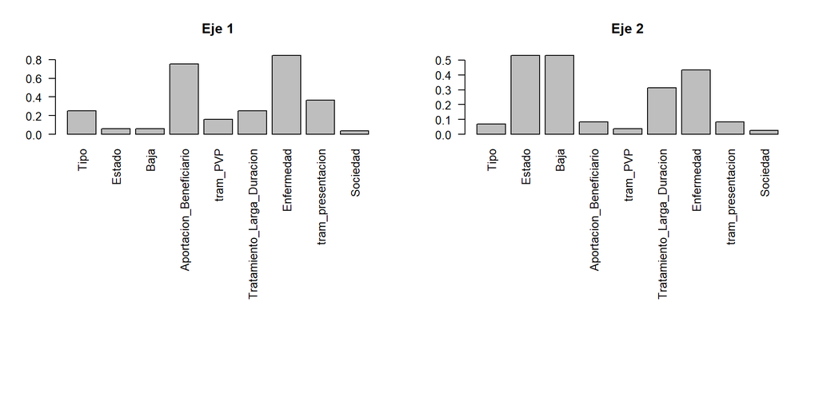

```r
# Generamos el gráfico de aportación de cada variable al primer y al segundo eje
par(mfrow = c(2, 2))
for (i in 1:2) barplot(acm$cr[, i], names.arg = row.names(acm$cr),
  las = 2, main = paste("Eje", i))
par(mfrow = c(1, 1))
```

Como podemos ver, la variable `Enfermedad`, es una variable que explica muy bien tanto la primera como la segunda dimension. Este hecho nos puede hacer pensar que es lo que nos pueden explicar los ejes. Viendo el histograma primero, vemos que para la primera dimension las variables `Enfermedad` y `Aportacion_Beneficiario` son las mas representativas. Por lo tanto podriamos definir que el primer eje habla de las características del paciente. El segundo eje lo podriamos definir como las características del uso del medicamento ya que vemos muy expresadas las variables `Estado`, `Baja`, `Tratamiento_Larga_Duracion` y `Enfermedad`.

Por lo tanto en resumen, podemos definir los ejes de la siguiente manera: - 1r eje: Características del paciente - 2n eje: Características del uso del medicamento

A continuación realizamos el gráfico.

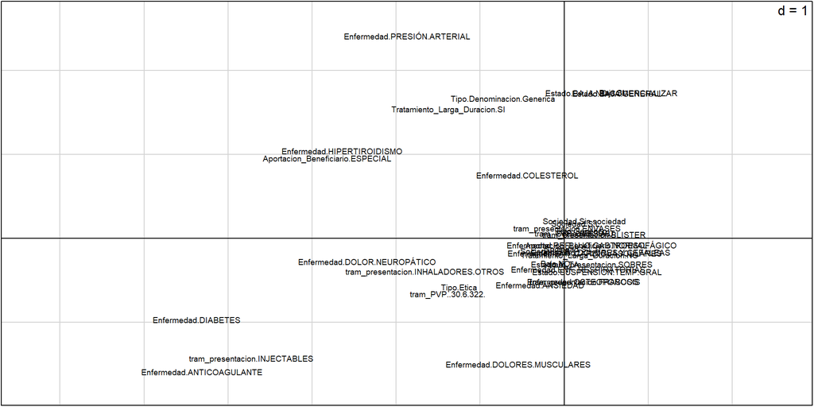

```r
# Generamos el gráfico de proyección de ACM
s.label(acm$co, clabel = 0.6, boxes = FALSE)
```

Aunque el gráfico no es del todo aclarador debido a que hay muchas categorias que solapan algunas etiquetas, podemos distingir que:

- Medicamentos que sirven para el tratamiento de la diabetis o anticoagulantes se sirven o se presentan en formato injectable.
- Los dolores musculares no se agrupan de ninguna forma en concreta.

-Podemos ver como los dolores neuropáticos se suministran con inhaladores. Nos extraña esta conclusión pero también cabe decir que estas categorias se encuentran cerca de los ejes x e y y por lo tanto significa que sus proyecciones no se representan de forma correcta.

- Otra de las conclusiones que podemos sacar es que aquellos medicamentos que son de tipo ético o tratamiento ético són aquellos que su coste está entre los 30 hasta los 322€. Por lo tanto vemos que la medicina ética es costosa y por eso són los hospitales que hacen uso de ellos.
- También podemos concluir que aquellas enfermedades de Hipertiroidismo tienen descuento en el precio del medicamento ya que se les catalóga como aportación ESPECIAL. Por lo tanto en los medicamentos relacionados con esas enfermedades tendrán un descuento más grande que otras enfermedades.

Si aumentaramos la zona central podriamos llegar a encontrar mas relaciones entre categorias. Cabe decir que no vamos a gastar recursos en hacerlo porque tal y como hemos explicado anteriormente, sus proyecciones estan muy cerca del centro de los ejes y eso nos está diciendo que no se representan correctamente.

Mediante el paquete `explor` de R permite a través de un shiny realizar el estudio ACM al completo.

# 8. Conclusiones y futuras lineas de trabajo

Como conclusiones del trabajo podemos decir que nos hemos dado cuenta de la importáncia del pre-processing de los datos ya que mucha de la información no se encuentra de forma tabular sinó que se han de seguir trabajando para obtenerlas tal y como las necesitamos.

También nos hemos dado cuenta de la importáncia de la transformación de los datos para obtener conclusiones a partir de los modelos.

También decir que hemos ido concluyendo cada apartado según ivamos resolviendo los problemas y por lo tanto se ha ido concluyendo cada apartado en el mismo.

# 9. Código

El código del proyecto se encuentra en el repositorio libre de Github. [Enlace](https://github.com/lmgeraldino/vademecum-consolidation).